# Sensitivity analyses

Rik J. Verheijden & Anna Cabané Ballester

2023-06-28

# 1 Introduction

In this script, we will conduct four sensitivity analyses:

- OS~PA restricted to patients with melanoma with additional adjustment for lactate dehydrogenase (LDH);
- OS~PA restricted to patients with ECOG performance status 0 and 1;
- SirAE~PA restricted to patients who received ipilimumab+nivolumab;
- SirAE~PA Fine and Gray subdistribution hazard model.

# 2 Prepare workspace

Because we are preparing the sensitivity analysis, the first part will be the same, but using only the melanoma subgroup and adding the LDH variable.

Empty R environment

```r
rm(list = ls())
```

Install packages

```r
install.packages("dplyr")
install.packages("tidyr")
install.packages("table1")
install.packages("gtsummary")
install.packages("ggplot2")
install.packages("rms")
install.packages("survival")
install.packages("cmprsk")
install.packages("tidycmprsk")
install.packages("survminer")
install.packages("ggsurvfit")
install.packages("ggpubr")
```

Activate packages

```r
library(dplyr)
library(tidyr)
library(table1)
library(gtsummary)
library(ggplot2)
library(rms)
library(survival)
library(cmprsk)
library(tidycmprsk)
library(survminer)
library(ggsurvfit)
library(ggpubr)
```

Functions to use in `table1()`. We use the `table1` package to make a table of patient characteristics. See the [vignette of table1](https://cran.r-project.org/web/packages/table1/vignettes/table1-examples.html) for more details. The functions below define how data are displayed within the table.

```r
    #function to exclude missings form percentages
my.render.cat <- function(x) {
  c("", sapply(stats.default(x), function(y) with(y,
                                                  if(PCTnoNA%in%c("NaN")){sprintf("")} #if all categories within one variable of a stratum are missing, no output
                                                  else{sprintf("%d (%0.1f%%)", FREQ, PCTnoNA)} #otherwise percentages excluding missings
                                                  )))
}

  #function to show percentage of missings if applicable
my.render.missing <- function(x, ...) {
  with(stats.apply.rounding(stats.default(is.na(x), ...), ...)$Yes,
       if(PCT==100){c(Missing = sprintf(""))} #if variable is missing for all subjects within this stratum, don't show missings
       else( c(Missing=sprintf("%s (%s%%)", FREQ, PCT))) #otherwise, show percentages of missings
      )
}
  #function to show continuous variables as median [Q1, Q3]
my.render.cont <- function(x, name, ...) {
  with(stats.default(x),
       c("", "median [Q1-Q3]"=sprintf("%s [%s-%s]"
                                      , round_pad(MEDIAN, digits=1)
                                      , round_pad(Q1, digits=1)
                                      , round_pad(Q3, digits=1)
                                      )))
}
```

Define working directory and load files

## 2.1 Load and prepare clinical data

Load the data after preprocessing to obtain physical activity variables from SQUASH questionnaire and clinical variables.

We will make some additional data frames for the subgroup analyses.

- `OS_melanoma`: for the sensitivity analysis of OS restricted to melanoma patients, we first use the subset melanoma patients and include the variable LDH in our analyses.
- `OS_PS`: for the sensitivity analysis of OS restricted to patient with ECOG performance status 0 or 1 (so excluding >1 and unknown).
- `tox_cICI`: for the sensitivity analysis of SirAEs restricted to patients who received ipilimumab+nivolumab.
- Note that we will use `data_OS` for the Fine and Gray subdistribution hazards model, since this also includes patients who started ICI less than one year before last follow-up.

We double check if we have missing values and if we can incorporate them or we need to exclude them from the sensitivity analysis.

Make `OS_melanoma`.

```r
data_OS$OS_status <- as.numeric(as.character(recode(data_OS$OS_status, "no"="0", "yes"="1")))
summary(data_OS$B_lab_LDH)
```

```
##    Min. 1st Qu.  Median    Mean 3rd Qu.    Max.    NA's
##    94.0   173.8   196.0   218.8   226.5  1124.0       3
```

```r
table(data_OS$B_tumor_type.1, useNA = "always")
```

```
##
## melanoma    NSCLC      RCC    other     <NA>
##      153       38       28       32        0
```

```r
OS_melanoma <- data_OS[data_OS$B_tumor_type.1 %in% "melanoma",]
summary(OS_melanoma$B_tumor_type.1)
```

```
## melanoma    NSCLC      RCC    other
##      153        0        0        0
```

```r
table(OS_melanoma$B_ther_cur_regrouped.1, useNA = "always")
```

```
##
##                 anti-PD-(L)1                         cICI
##                          119                           34
## ICI + chemo/targeted therapy                         <NA>
##                            0                            0
```

```r
OS_melanoma$B_ther_cur_regrouped.1 <- droplevels(OS_melanoma$B_ther_cur_regrouped.1)
OS_melanoma[is.na(OS_melanoma$B_lab_LDH),c("record_id","B_lab_LDH")]
```

```
## [1] record_id B_lab_LDH
## <0 rows> (or 0-length row.names)
```

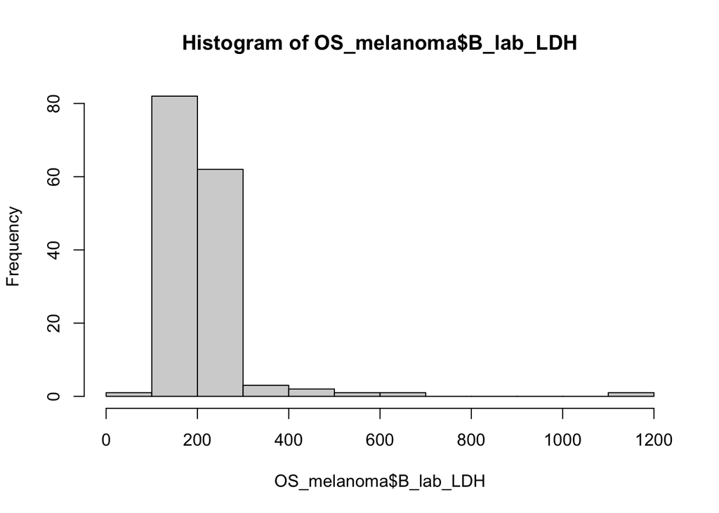

```r
hist(OS_melanoma$B_lab_LDH)
```

```r
# OS_melanoma[OS_melanoma$B_lab_LDH=="1124",]$record_id #checked --> correct
```

We checked the outlier with LDH of 1124U/L in electronic patient files and it is correct.

# 3 OS~PA Melanoma subgroup

## 3.1 Baseline characteristics

Specify data frame to use

```r
OS_melanoma$B_lab_LDH_ULN<- cut(OS_melanoma$B_lab_LDH, breaks = c(0, 250, 500, (max(OS_melanoma$B_lab_LDH)+1)),
                        labels = c("<1x ULN", "1-2x ULN", ">2x ULN"))
table(OS_melanoma$B_lab_LDH_ULN, useNA = "always")
```

```
##
##  <1x ULN 1-2x ULN  >2x ULN     <NA>
##      136       14        3        0
```

```r
data <- OS_melanoma

data$B_tumor_stage_dich <- factor(ifelse(data$B_tumor_stage%in%c("III","IIIA","IIIB","IIIC","IIID"),"III",
                                  ifelse(data$B_tumor_stage%in%c("IV","IVA","IVB","IVC","IVD"), "IV",
                                  ifelse(data$B_tumor_stage%in%"other","other",
                                         NA))),
                                  levels = c("III","IV", "other"))
```

Relabel variables and add units that you want to use in your table (all formatting to let the table look nicely):

```r
label(data$B_sex) <- "sex"
label(data$B_age) <- "age"
units(data$B_age) <- "years"
label(data$B_PS) <- "ECOG performance status"
label(data$B_tumor_type.1) <- "tumor type"
label(data$B_tumor_stage_dich) <- "stage"
label(data$B_paladj) <- "treatment intent"
label(data$B_ther_cur_regrouped.1) <- "therapy"
label(data$T1_gr3_1y) <- "severe irAE within 1 year"
label(data$B_lab_LDH) <- "lactate dehydrogenase"
label (data$B_lab_LDH_ULN) <- "lactate dehydrogenase"
label(data$totmet_hpwk_tertiles) <- "MET-hours per week"
label(data$totmet_hpwk) <- "MET-hours"
units(data$totmet_hpwk) <- "hours/week"
label(data$MZvt_HWK) <- "MVPA-SL"
units(data$MZvt_HWK) <- "hours/week"
```

Make the actual table:

- `~ B_sex + B_age + ... + B_ther_cur_regrouped.1` defines the rows;
- `| totmet_hpwk_tertiles` defines the columns;
- the rest are just to change the appearance of the table.

```r
table1(~ totmet_hpwk + MZvt_HWK + B_sex + B_age + B_PS + B_tumor_type.1 + B_tumor_stage_dich + B_lab_LDH_ULN + B_paladj + B_ther_cur_regrouped.1| totmet_hpwk_tertiles,
       data = data,
       overall = "Overall",
       # caption = "Table 1: baseline characteristics of combined ipilimumab",
       # footnote = "RCC: renal cell carcinoma",
       topclass = "Rtable1-zebra",
       render.categorical = my.render.cat,
       render.continuous = my.render.cont,#c(.="median [Q1, Q3]"),
       render.missing = my.render.missing,
       droplevels = TRUE)
```

|  | [0,51] (N=40) | (51,101] (N=54) | (101,371] (N=59) | Overall (N=153) |
| --- | --- | --- | --- | --- |
| MET-hours (hours/week) |  |  |  |  |
| median [Q1-Q3] | 38.2 [28.0-41.7] | 75.4 [62.0-87.0] | 132.3 [112.0-171.7] | 83.8 [47.3-119.8] |
| MVPA-SL (hours/week) |  |  |  |  |
| median [Q1-Q3] | 1.0 [0.0-3.5] | 4.6 [1.5-6.5] | 10.0 [5.0-17.7] | 4.7 [1.0-9.5] |
| sex |  |  |  |  |
| male | 20 (50.0%) | 40 (74.1%) | 37 (62.7%) | 97 (63.4%) |
| female | 20 (50.0%) | 14 (25.9%) | 22 (37.3%) | 56 (36.6%) |
| age (years) |  |  |  |  |
| median [Q1-Q3] | 67.5 [59.8-72.3] | 64.0 [52.5-73.0] | 62.0 [54.5-71.5] | 64.0 [54.0-73.0] |
| ECOG performance status |  |  |  |  |
| 0 | 18 (45.0%) | 30 (55.6%) | 42 (71.2%) | 90 (58.8%) |
| 1 | 20 (50.0%) | 21 (38.9%) | 13 (22.0%) | 54 (35.3%) |
| 2 | 2 (5.0%) | 1 (1.9%) | 2 (3.4%) | 5 (3.3%) |
| 3 | 0 (0.0%) | 0 (0.0%) | 0 (0.0%) | 0 (0.0%) |
| 4 | 0 (0.0%) | 0 (0.0%) | 0 (0.0%) | 0 (0.0%) |
| unknown | 0 (0.0%) | 2 (3.7%) | 2 (3.4%) | 4 (2.6%) |
| tumor type |  |  |  |  |
| melanoma | 40 (100.0%) | 54 (100.0%) | 59 (100.0%) | 153 (100.0%) |
| NSCLC | 0 (0.0%) | 0 (0.0%) | 0 (0.0%) | 0 (0.0%) |
| RCC | 0 (0.0%) | 0 (0.0%) | 0 (0.0%) | 0 (0.0%) |
| other | 0 (0.0%) | 0 (0.0%) | 0 (0.0%) | 0 (0.0%) |
| stage |  |  |  |  |
| III | 17 (42.5%) | 33 (61.1%) | 38 (64.4%) | 88 (57.5%) |
| IV | 22 (55.0%) | 21 (38.9%) | 21 (35.6%) | 64 (41.8%) |
| other | 1 (2.5%) | 0 (0.0%) | 0 (0.0%) | 1 (0.7%) |
| lactate dehydrogenase |  |  |  |  |
| <1x ULN | 31 (77.5%) | 53 (98.1%) | 52 (88.1%) | 136 (88.9%) |
| 1-2x ULN | 8 (20.0%) | 1 (1.9%) | 5 (8.5%) | 14 (9.2%) |
| >2x ULN | 1 (2.5%) | 0 (0.0%) | 2 (3.4%) | 3 (2.0%) |
| treatment intent |  |  |  |  |
| palliative | 24 (60.0%) | 19 (35.2%) | 20 (33.9%) | 63 (41.2%) |
| adjuvant | 16 (40.0%) | 35 (64.8%) | 39 (66.1%) | 90 (58.8%) |
| therapy |  |  |  |  |
| anti-PD-(L)1 | 28 (70.0%) | 45 (83.3%) | 46 (78.0%) | 119 (77.8%) |
| cICI | 12 (30.0%) | 9 (16.7%) | 13 (22.0%) | 34 (22.2%) |

Indeed we selected only melanoma patients.

## 3.2 OS~MET melanoma subgroup

To confirm the results for overall survival we will perform the Cox proportional hazard regression and KM curves, to asses the correlation of total MET hours per week (`totmet_hpwk_tertiles`) and MVPA-SL (`MZvt_HWK_tertiles`), in different functional forms - categorial: tertiles by sample size of overall dataset - continuous: splines to see whether shape is similar to all patients

### 3.2.1 OS~MET melanoma subgroup Kaplan Meier curves - tertiles

We first flip the order of levels of `totmet_hpwk_tertiles`, since it appears that patients with highest values have better survival and thus it is more intuitive.

```r
OS_melanoma$totmet_hpwk_tertiles_KM <- factor(OS_melanoma$totmet_hpwk_tertiles
                                          , levels = rev(levels(OS_melanoma$totmet_hpwk_tertiles)))
fit_tert.crude <- survfit(Surv(OS_days, OS_status)~ totmet_hpwk_tertiles_KM ,
                          data = OS_melanoma)
KM_OS_MET_mel <- ggsurvplot(fit_tert.crude
                     ,conf.int = F
                     ,pval = F
                     ,xscale="d_m"
                     ,break.x.by=30.4375*6
                     # ,title=""
                     ,xlab="Time (months)"
                     ,ylab="Survival probability"
                     ,legend = c(.28,.28)
                     ,legend.title="MET-hours"
                     ,legend.labs=c(paste0("high ",
                                           levels(OS_melanoma$totmet_hpwk_tertiles_KM)[1]),
                                    paste0("moderate ",
                                           levels(OS_melanoma$totmet_hpwk_tertiles_KM)[2]),
                                    paste0("low ",
                                           levels(OS_melanoma$totmet_hpwk_tertiles_KM)[3]))
                     ,axes.offset=F
                     ,surv.median.line = "none"
                     ,consor=T
                     ,censor.shape=124
                     ,censor.size=2
                     ,risk.table = T
                     ,risk.table.y.text=F
                     ,fontsize=3.5
                     ,ggtheme = theme_survminer(font.x = 12, font.y=12, font.main=12, font.tickslab=10, font.legend=10)
                     ,tables.theme = theme_cleantable(base_size = 10, font.x=10, font.y=10, font.main=12)
          )
KM_OS_MET_mel
```

### 3.2.2 OS~MET melanoma subgroup Cox regression - tertiles

Adjusted Cox regression for tertiles linear variable

```r
cox_tert.adj <- coxph(Surv(OS_days, OS_status)~ totmet_hpwk_tertiles + B_sex + B_age + B_paladj + B_ther_cur_regrouped.1 + B_lab_LDH,
                      data = OS_melanoma)
tbl_regression(cox_tert.adj, exponentiate=T)
```

| **Characteristic** | **HR**<sup>1</sup> | **95% CI**<sup>1</sup> | **p-value** |
| --- | --- | --- | --- |
| totmet_hpwk_tertiles |  |  |  |
| [0,51] | — | — |  |
| (51,101] | 0.82 | 0.32, 2.11 | 0.7 |
| (101,371] | 0.69 | 0.26, 1.81 | 0.4 |
| B_sex |  |  |  |
| male | — | — |  |
| female | 1.24 | 0.56, 2.72 | 0.6 |
| B_age | 0.99 | 0.96, 1.01 | 0.3 |
| B_paladj |  |  |  |
| palliative | — | — |  |
| adjuvant | 0.46 | 0.17, 1.20 | 0.11 |
| B_ther_cur_regrouped.1 |  |  |  |
| anti-PD-(L)1 | — | — |  |
| cICI | 0.93 | 0.30, 2.88 | >0.9 |
| B_lab_LDH | 1.00 | 1.00, 1.00 | 0.7 |

<sup>1</sup> HR = Hazard Ratio, CI = Confidence Interval

### 3.2.3 OS~MET melanoma subgroup Cox regression - splines

Define positions of knots.

```r
k.pos.totmet_hpwk <- rcspline.eval(OS_melanoma$totmet_hpwk #variable to use splines for
                            , nk= 3#number of knots
                            , inclx=FALSE
                            , knots.only=T #only store knots
                            , type="ordinary"
                            , norm=2
                            , rpm=NULL
                            , pc=FALSE
                            , fractied=0.05)
```

Run initial regression.

```r
cox_rcs.adj <- coxph(Surv(OS_days, OS_status)~ rms::rcs(totmet_hpwk, k.pos.totmet_hpwk) + B_sex + B_age + B_paladj + B_ther_cur_regrouped.1 + B_lab_LDH,
                     data = OS_melanoma)

tbl_regression(cox_rcs.adj, exponentiate=T)
```

| **Characteristic** | **HR**<sup>1</sup> | **95% CI**<sup>1</sup> | **p-value** |
| --- | --- | --- | --- |
| totmet_hpwk |  |  |  |
| rms::rcs(totmet_hpwk, k.pos.totmet_hpwk)totmet_hpwk | 0.99 | 0.97, 1.00 | 0.14 |
| rms::rcs(totmet_hpwk, k.pos.totmet_hpwk)totmet_hpwk' | 1.02 | 0.99, 1.04 | 0.2 |
| B_sex |  |  |  |
| male | — | — |  |
| female | 1.18 | 0.53, 2.60 | 0.7 |
| B_age | 0.98 | 0.96, 1.01 | 0.2 |
| B_paladj |  |  |  |
| palliative | — | — |  |
| adjuvant | 0.44 | 0.17, 1.14 | 0.091 |
| B_ther_cur_regrouped.1 |  |  |  |
| anti-PD-(L)1 | — | — |  |
| cICI | 0.85 | 0.27, 2.67 | 0.8 |
| B_lab_LDH | 1.00 | 1.0, 1.00 | 0.7 |

<sup>1</sup> HR = Hazard Ratio, CI = Confidence Interval

##### 3.2.3.0.1 Check added value of using splines

We can check whether using restricted cubic splines improves the model fit (statistically). A p-value <0.05 indicates that the model fit is statistically different.

We can check whether `totmet_hpwk` improves the model fit at all (compare a model with splines for `totmet_hpwk` (*Model 1*) to a model without `totmet_hpwk` (*Model 2*)).

```r
anova(cox_rcs.adj,update(cox_rcs.adj,.~.-rms::rcs(totmet_hpwk, k.pos.totmet_hpwk)))
```

```
## Analysis of Deviance Table
##  Cox model: response is  Surv(OS_days, OS_status)
##  Model 1: ~ rms::rcs(totmet_hpwk, k.pos.totmet_hpwk) + B_sex + B_age + B_paladj + B_ther_cur_regrouped.1 + B_lab_LDH
##  Model 2: ~ B_sex + B_age + B_paladj + B_ther_cur_regrouped.1 + B_lab_LDH
##    loglik  Chisq Df Pr(>|Chi|)
## 1 -109.51
## 2 -110.54 2.0522  2     0.3584
```

Than, we check whether using splines for `totmet_hpwk` gives a better fit than adding it as a linear variable (compare a model with splines for `totmet_hpwk` (*Model 1*) to a model with `totmet_hpwk` as is (*Model 2*)).

```r
anova(cox_rcs.adj,update(cox_rcs.adj,.~.-rms::rcs(totmet_hpwk, k.pos.totmet_hpwk)+totmet_hpwk))
```

```
## Analysis of Deviance Table
##  Cox model: response is  Surv(OS_days, OS_status)
##  Model 1: ~ rms::rcs(totmet_hpwk, k.pos.totmet_hpwk) + B_sex + B_age + B_paladj + B_ther_cur_regrouped.1 + B_lab_LDH
##  Model 2: ~ B_sex + B_age + B_paladj + B_ther_cur_regrouped.1 + B_lab_LDH + totmet_hpwk
##    loglik  Chisq Df Pr(>|Chi|)
## 1 -109.51
## 2 -110.43 1.8346  1     0.1756
```

Thus, using restricted cubic splines for `totmet_hpwk` does NOT improve our model fit..

Make dummy database.

```r
newdf <- with(OS_melanoma,
              expand.grid(totmet_hpwk=c(seq(min(totmet_hpwk),max(totmet_hpwk),length=300), k.pos.totmet_hpwk)
                          , B_sex = levels(B_sex)[1] #reference level for sex
                          , B_age = 0 #reference age for age (note, you could also use e.g. median, this wouldn't change the results)
                          , B_tumor_type.1 = levels(B_tumor_type.1)[1]
                          , B_paladj = levels(B_paladj)[1]
                          , B_ther_cur_regrouped.1 = levels(B_ther_cur_regrouped.1)[1]
                          , B_lab_LDH = 0
                          ))
```

Now we make a model matrix (= some technical stuff needed for next step).

```r
mm <- model.matrix(cox_rcs.adj,data=newdf)
mm[,!colnames(mm) %in% colnames(mm)[grep("totmet_hpwk",colnames(mm))]] <- 0 # set all variables not about totmet_hpwk to 0
```

For each value of our sequence of `totmet_hpwk`, we obtain its predicted coefficient (=`eta`) and predicted standard error (=`pse`). With these, we compute the predicted 95% confidence intervals (`plo` and `phi` for lower and upper CI). We store these in a data frame called `est`.

```r
est <- data.frame(totmet_hpwk=newdf$totmet_hpwk,eta=mm%*%coef(cox_rcs.adj)) #predicted coefficient
pvar <- diag(mm %*% tcrossprod(vcov(cox_rcs.adj),mm)) #predicted variance
est <- data.frame(est,pse=sqrt(pvar)) #predicted standard error
est <- with(est,
            data.frame(est,
                       plo=eta-qnorm(0.975)*pse, #predicted lower 95%CI bound
                       phi=eta+qnorm(0.975)*pse)) #predicted upper 95%CI bound
```

For Cox regression and logistic regression we need to exponentiate the coefficient and confidence bounds to obtain HR and 95% CI.

```r
est[,c("eta","plo","phi")] <- exp(est[,c("eta","plo","phi")])
```

We remove duplicates (e.g. if we have two of the same values for `totmet_hpwk`) and sort on `totmet_hpwk`.

```r
est <- est[!duplicated(est),] #remove duplicates
est <- est[order(est$totmet_hpwk),] #sort based on var1 order
```

##### 3.2.3.0.2 Make splines plot

Now, we can finally make the actual plot.

```r
p_splines_OS_MET_mel <- ggplot(data = est
                )+ geom_ribbon(aes(x=totmet_hpwk, ymin = plo, ymax = phi) #color 95%CI
                               , colour = rgb(248,136,44,maxColorValue = 255,alpha=100)
                               , fill=rgb(252,211,178,maxColorValue = 255,alpha=100)
                               , alpha=0.4
                )+ geom_hline(yintercept=1 #add horizontal line at 1
                              , color="dark grey"
                              , linetype="dashed"
                              , linewidth=1
                )+ geom_line(aes(x=totmet_hpwk,y=eta) #add estimated HR
                             , color = "coral3"
                             , linewidth = 1
                )+ geom_point(data=est[est$totmet_hpwk%in%k.pos.totmet_hpwk,] #to plot the places of the knots
                              , aes(x=totmet_hpwk, y=eta)
                )+ geom_rug(data = OS_melanoma, aes(x=totmet_hpwk) #add rugs representing real observations for totmet_hpwk
                            , sides = "b"
                            , length = grid::unit(0.02, "npc")
                            , color = "grey"
                            , alpha = .3
                )+ scale_x_continuous(expand = c(0, 0) #set axes directly at 0
                )+ scale_y_log10(breaks = unique(c(0.1,seq(0,1,.2), seq(0,1,.2)*10))
                # )+ annotation_logticks(base = 10, sides = "l", outside=F , scaled = T, color = "black",alpha = .5
                )+ coord_cartesian(#xlim = c(0, 201) #set x-axis
                                   ylim = c(0.1,10) #set y-axis
                # )+ ggtitle("" #add title
                )+ xlab("MET-hours (/week)" #add x-axis label
                )+ ylab("Hazard ratio for death" #add y-axis label
                )+ theme_light( #add/alter theme
                )+ theme(plot.margin = margin(0.5,3,0.5,0.5, unit = "char")
                )

p_splines_OS_MET_mel
```

## 3.3 OS~MVPASL melanoma subgroup

### 3.3.1 OS~MVPASL melanoma subgroup Kaplan Meier curves - tertiles

Kaplan Meier curve for tertiles (=unadjusted)

```r
OS_melanoma$MZvt_HWK_tertiles_KM <- factor(OS_melanoma$MZvt_HWK_tertiles
                                          , levels = rev(levels(OS_melanoma$MZvt_HWK_tertiles)))
fit_tert.crude <- survfit(Surv(OS_days, OS_status)~ MZvt_HWK_tertiles_KM ,
                          data = OS_melanoma)
KM_OS_MVPASL_mel <- ggsurvplot(fit_tert.crude
                     ,conf.int = F
                     ,pval = F
                     ,xscale="d_m"
                     ,break.x.by=30.4375*6
                     # ,title=""
                     ,xlab="Time (months)"
                     ,ylab="Survival probability"
                     ,legend = c(.28,.28)
                     ,legend.title="MET-hours"
                     ,legend.labs=c(paste0("high ",
                                           levels(OS_melanoma$MZvt_HWK_tertiles_KM)[1]),
                                    paste0("moderate ",
                                           levels(OS_melanoma$MZvt_HWK_tertiles_KM)[2]),
                                    paste0("low ",
                                           levels(OS_melanoma$MZvt_HWK_tertiles_KM)[3]))
                     ,axes.offset=F
                     ,surv.median.line = "none"
                     ,consor=T
                     ,censor.shape=124
                     ,censor.size=2
                     ,risk.table = T
                     ,risk.table.y.text=F
                     ,fontsize=3.5
                     ,ggtheme = theme_survminer(font.x = 12, font.y=12, font.main=12, font.tickslab=10, font.legend=10)
                     ,tables.theme = theme_cleantable(base_size = 10, font.x=10, font.y=10, font.main=12)
          )
KM_OS_MVPASL_mel
```

### 3.3.2 OS~MVPASL melanoma subgroup Cox regression - tertiles

Adjusted Cox regression for tertiles linear variable

```r
cox_tert.adj <- coxph(Surv(OS_days, OS_status)~ MZvt_HWK_tertiles + B_sex + B_age + B_paladj + B_ther_cur_regrouped.1 + B_lab_LDH,
                      data = OS_melanoma)
tbl_regression(cox_tert.adj, exponentiate=T)
```

| **Characteristic** | **HR**<sup>1</sup> | **95% CI**<sup>1</sup> | **p-value** |
| --- | --- | --- | --- |
| MZvt_HWK_tertiles |  |  |  |
| [0,1.5] | — | — |  |
| (1.5,6.5] | 0.44 | 0.16, 1.19 | 0.10 |
| (6.5,38.5] | 0.59 | 0.21, 1.63 | 0.3 |
| B_sex |  |  |  |
| male | — | — |  |
| female | 1.01 | 0.44, 2.34 | >0.9 |
| B_age | 0.98 | 0.96, 1.01 | 0.2 |
| B_paladj |  |  |  |
| palliative | — | — |  |
| adjuvant | 0.41 | 0.16, 1.08 | 0.070 |
| B_ther_cur_regrouped.1 |  |  |  |
| anti-PD-(L)1 | — | — |  |
| cICI | 0.83 | 0.27, 2.50 | 0.7 |
| B_lab_LDH | 1.00 | 1.00, 1.00 | 0.7 |

<sup>1</sup> HR = Hazard Ratio, CI = Confidence Interval

### 3.3.3 OS~MVPASL melanoma subgroup Cox regression - splines

#### 3.3.3.1 Knot specification

Specify knot locations.

```r
k.pos.MZvt_HWK <- rcspline.eval(OS_melanoma$MZvt_HWK #variable to use splines for
                            , nk=3 #number of knots
                            , inclx=FALSE
                            , knots.only=T #only store knots
                            , type="ordinary"
                            , norm=2
                            , rpm=NULL
                            , pc=FALSE
                            , fractied=0.05)
```

Initial regression.

```r
cox_rcs.adj <- coxph(Surv(OS_days, OS_status)~ rms::rcs(MZvt_HWK, k.pos.MZvt_HWK) + B_sex + B_age + B_paladj + B_ther_cur_regrouped.1 + B_lab_LDH,
                     data = OS_melanoma)
tbl_regression(cox_rcs.adj, exponentiate = T)
```

| **Characteristic** | **HR**<sup>1</sup> | **95% CI**<sup>1</sup> | **p-value** |
| --- | --- | --- | --- |
| MZvt_HWK |  |  |  |
| rms::rcs(MZvt_HWK, k.pos.MZvt_HWK)MZvt_HWK | 0.79 | 0.64, 0.97 | 0.027 |
| rms::rcs(MZvt_HWK, k.pos.MZvt_HWK)MZvt_HWK' | 1.51 | 1.06, 2.14 | 0.022 |
| B_sex |  |  |  |
| male | — | — |  |
| female | 1.11 | 0.48, 2.56 | 0.8 |
| B_age | 0.98 | 0.96, 1.01 | 0.3 |
| B_paladj |  |  |  |
| palliative | — | — |  |
| adjuvant | 0.42 | 0.16, 1.07 | 0.070 |
| B_ther_cur_regrouped.1 |  |  |  |
| anti-PD-(L)1 | — | — |  |
| cICI | 0.85 | 0.28, 2.58 | 0.8 |
| B_lab_LDH | 1.00 | 1.00, 1.00 | 0.8 |

<sup>1</sup> HR = Hazard Ratio, CI = Confidence Interval

##### 3.3.3.1.1 Check added value of using splines

We can check whether using restricted cubic splines improves the model fit (statistically). A p-value <0.05 indicates that the model fit is statistically different.

We can check whether `MZvt_HWK` improves the model fit at all (compare a model with splines for `MZvt_HWK` (*Model 1*) to a model without `MZvt_HWK` (*Model 2*)).

```r
anova(cox_rcs.adj,update(cox_rcs.adj,.~.-rms::rcs(MZvt_HWK, k.pos.MZvt_HWK)))
```

```
## Analysis of Deviance Table
##  Cox model: response is  Surv(OS_days, OS_status)
##  Model 1: ~ rms::rcs(MZvt_HWK, k.pos.MZvt_HWK) + B_sex + B_age + B_paladj + B_ther_cur_regrouped.1 + B_lab_LDH
##  Model 2: ~ B_sex + B_age + B_paladj + B_ther_cur_regrouped.1 + B_lab_LDH
##    loglik Chisq Df Pr(>|Chi|)
## 1 -107.89
## 2 -110.54 5.296  2    0.07079 .
## ---
## Signif. codes:  0 '***' 0.001 '**' 0.01 '*' 0.05 '.' 0.1 ' ' 1
```

Than, we check whether using splines for `MZvt_HWK` gives a better fit than adding it as a linear variable (compare a model with splines for `MZvt_HWK` (*Model 1*) to a model with `MZvt_HWK` as is (*Model 2*)).

```r
anova(cox_rcs.adj,update(cox_rcs.adj,.~.-rms::rcs(MZvt_HWK, k.pos.MZvt_HWK)+MZvt_HWK))
```

```
## Analysis of Deviance Table
##  Cox model: response is  Surv(OS_days, OS_status)
##  Model 1: ~ rms::rcs(MZvt_HWK, k.pos.MZvt_HWK) + B_sex + B_age + B_paladj + B_ther_cur_regrouped.1 + B_lab_LDH
##  Model 2: ~ B_sex + B_age + B_paladj + B_ther_cur_regrouped.1 + B_lab_LDH + MZvt_HWK
##    loglik  Chisq Df Pr(>|Chi|)
## 1 -107.89
## 2 -110.50 5.2166  1    0.02237 *
## ---
## Signif. codes:  0 '***' 0.001 '**' 0.01 '*' 0.05 '.' 0.1 ' ' 1
```

Make dummy dataset.

```r
newdf <- with(OS_melanoma,
              expand.grid(MZvt_HWK=c(seq(min(MZvt_HWK),max(MZvt_HWK),length=200), k.pos.MZvt_HWK)
                          , B_sex = levels(B_sex)[1] #reference level for sex
                          , B_age = 0 #reference age for age (note, you could also use e.g. median, this wouldn't change the results)
                          , B_paladj = levels(B_paladj)[1]
                          , B_ther_cur_regrouped.1 = levels(B_ther_cur_regrouped.1)[1]
                          , B_lab_LDH = 0
                          ))
```

Now we make a model matrix (= some technical stuff needed for next step).

```r
mm <- model.matrix(cox_rcs.adj,data=newdf)
mm[,!colnames(mm) %in% colnames(mm)[grep("MZvt_HWK",colnames(mm))]] <- 0 # set all variables not about MZvt_HWK to 0
```

For each value of our sequence of `MZvt_HWK`, we obtain its predicted coefficient (=`eta`) and predicted standard error (=`pse`). With these, we compute the predicted 95% conficence intervalls (`plo` and `phi` for lower and upper CI). We store these in a data frame called `est`.

```r
est <- data.frame(MZvt_HWK=newdf$MZvt_HWK,eta=mm%*%coef(cox_rcs.adj)) #predicted coefficient
pvar <- diag(mm %*% tcrossprod(vcov(cox_rcs.adj),mm)) #predicted variance
est <- data.frame(est,pse=sqrt(pvar)) #predicted standard error
est <- with(est,
            data.frame(est,
                       plo=eta-qnorm(0.975)*pse, #predicted lower 95%CI bound
                       phi=eta+qnorm(0.975)*pse)) #predicted upper 95%CI bound
```

For Cox regression and logistic regression we need to exponentiate the coefficient and confidence bounds to obtain HR and 95% CI.

```r
est[,c("eta","plo","phi")] <- exp(est[,c("eta","plo","phi")])
```

We remove duplicates (e.g. if we have two of the same values for `MZvt_HWK`) and sort on `MZvt_HWK`.

```r
est <- est[!duplicated(est),] #remove duplicates
est <- est[order(est$MZvt_HWK),] #sort based on var1 order
```

##### 3.3.3.1.2 Make splines plot

```r
p_splines_OS_MVPASL_mel <- ggplot(data = est
                )+ geom_ribbon(aes(x=MZvt_HWK, ymin = plo, ymax = phi) #color 95%CI
                               , colour = rgb(248,136,44,maxColorValue = 255,alpha=100)
                               , fill=rgb(252,211,178,maxColorValue = 255,alpha=100)
                               , alpha=0.4
                )+ geom_hline(yintercept=1 #add horizontal line at 1
                              , color="dark grey"
                              , linetype="dashed"
                              , linewidth=1
                )+ geom_line(aes(x=MZvt_HWK,y=eta) #add estimated HR
                             , color = "coral3"
                             , linewidth = 1
                )+ geom_point(data=est[est$MZvt_HWK%in%k.pos.MZvt_HWK,] #to plot the places of the knots
                              , aes(x=MZvt_HWK, y=eta)
                )+ geom_rug(data = OS_melanoma, aes(x=MZvt_HWK) #add rugs representing real observations for MZvt_HWK
                            , sides = "b"
                            , length = grid::unit(0.02, "npc")
                            , color = "grey"
                            , alpha = .5
                )+ scale_x_continuous(expand = c(0,0) #set axes directly at 0
                )+ scale_y_log10(breaks = unique(c(0.1,seq(0,1,.2), seq(0,1,.2)*10))
                # )+ annotation_logticks(base = 10, sides = "l", outside=F , scaled = T, color = "black",alpha = .5
                )+ coord_cartesian(#xlim = c(0, 30) #set x-axis
                            ylim = c(0.1,10) #set y-axis
                # )+ ggtitle("" #add title
                )+ xlab("MVPA-SL (hours/week)" #add x-axis label
                )+ ylab("Hazard ratio for death" #add y-axis label
                )+ theme_light( #add/alter theme
                )+ theme(plot.margin = margin(0.5,3,0.5,0.5, unit = "char")
                )
p_splines_OS_MVPASL_mel
```

## 3.4 Combine all OS plots

Make Supplementary Figure 4.

```r
KM_OS_MET_mel <- ggarrange(KM_OS_MET_mel$plot,KM_OS_MET_mel$table
                       , ncol=1, nrow=2
                       , heights= c(.75,.25))
KM_OS_MVPASL_mel <- ggarrange(KM_OS_MVPASL_mel$plot,KM_OS_MVPASL_mel$table
                       , ncol=1, nrow=2
                       , heights= c(.75,.25))

suppl_figure4 <- ggarrange(KM_OS_MET_mel, p_splines_OS_MET_mel,
                     KM_OS_MVPASL_mel, p_splines_OS_MVPASL_mel
                     ,labels = c("A","B","C","D")
                     ,ncol=2, nrow=2
                     ,widths = c(1,1), heights = c(1,1)
                     ,common.legend=F
                     )
suppl_figure4
```

Save as PDF.

# 4 OS~PA ECOG PS 0-1 subgroup

Make `OS_PS`.

```r
OS_PS <- data_OS[data_OS$B_PS%in%c("0","1"),]
table(OS_PS$B_ther_cur_regrouped.1, useNA = "always")
```

```
##
##                 anti-PD-(L)1                         cICI
##                          151                           53
## ICI + chemo/targeted therapy                         <NA>
##                           23                            0
```

```r
table(OS_PS$B_tumor_type.1, useNA = "always")
```

```
##
## melanoma    NSCLC      RCC    other     <NA>
##      144       34       20       29        0
```

## 4.1 Baseline characteristics

Specify data frame to use

```r
data <- OS_PS
data$B_tumor_stage_dich <- factor(ifelse(data$B_tumor_stage%in%c("III","IIIA","IIIB","IIIC","IIID"),"III",
                                  ifelse(data$B_tumor_stage%in%c("IV","IVA","IVB","IVC","IVD"), "IV",
                                  ifelse(data$B_tumor_stage%in%"other","other",
                                         NA))),
                                  levels = c("III","IV", "other"))
```

Relabel variables and add units that you want to use in your table (all formatting to let the table look nicely):

```r
label(data$B_sex) <- "sex"
label(data$B_age) <- "age"
units(data$B_age) <- "years"
label(data$B_PS) <- "ECOG performance status"
label(data$B_tumor_type.1) <- "tumor type"
label(data$B_tumor_stage_dich) <- "stage"
label(data$B_paladj) <- "treatment intent"
label(data$B_ther_cur_regrouped.1) <- "therapy"
label(data$T1_gr3_1y) <- "severe irAE within 1 year"
label(data$totmet_hpwk_tertiles) <- "MET-hours per week"
label(data$totmet_hpwk) <- "MET-hours"
units(data$totmet_hpwk) <- "hours/week"
label(data$MZvt_HWK) <- "MVPA-SL"
units(data$MZvt_HWK) <- "hours/week"
```

Make the actual table:

- `~ B_sex + B_age + ... + B_ther_cur_regrouped.1` defines the rows;
- `| totmet_hpwk_tertiles` defines the columns;
- the rest are just to change the appearance of the table.

```r
table1(~ totmet_hpwk + MZvt_HWK + B_sex + B_age + B_PS + B_tumor_type.1 + B_tumor_stage_dich + B_paladj + B_ther_cur_regrouped.1| totmet_hpwk_tertiles,
       data = data,
       overall = "Overall",
       # caption = "Table 1: baseline characteristics of combined ipilimumab",
       # footnote = "RCC: renal cell carcinoma",
       topclass = "Rtable1-zebra",
       render.categorical = my.render.cat,
       render.continuous = my.render.cont,#c(.="median [Q1, Q3]"),
       render.missing = my.render.missing,
       droplevels = TRUE)
```

|  | [0,51] (N=69) | (51,101] (N=80) | (101,371] (N=78) | Overall (N=227) |
| --- | --- | --- | --- | --- |
| MET-hours (hours/week) |  |  |  |  |
| median [Q1-Q3] | 35.1 [22.9-41.3] | 75.4 [62.0-85.9] | 131.1 [112.6-173.0] | 77.8 [42.2-113.6] |
| MVPA-SL (hours/week) |  |  |  |  |
| median [Q1-Q3] | 1.0 [0.0-3.0] | 5.0 [1.9-8.1] | 8.9 [4.0-15.0] | 4.0 [1.0-8.5] |
| sex |  |  |  |  |
| male | 41 (59.4%) | 58 (72.5%) | 48 (61.5%) | 147 (64.8%) |
| female | 28 (40.6%) | 22 (27.5%) | 30 (38.5%) | 80 (35.2%) |
| age (years) |  |  |  |  |
| median [Q1-Q3] | 66.0 [59.0-73.0] | 65.0 [54.0-73.0] | 61.0 [54.0-69.0] | 64.0 [54.0-72.0] |
| ECOG performance status |  |  |  |  |
| 0 | 31 (44.9%) | 39 (48.8%) | 56 (71.8%) | 126 (55.5%) |
| 1 | 38 (55.1%) | 41 (51.2%) | 22 (28.2%) | 101 (44.5%) |
| 2 | 0 (0.0%) | 0 (0.0%) | 0 (0.0%) | 0 (0.0%) |
| 3 | 0 (0.0%) | 0 (0.0%) | 0 (0.0%) | 0 (0.0%) |
| 4 | 0 (0.0%) | 0 (0.0%) | 0 (0.0%) | 0 (0.0%) |
| unknown | 0 (0.0%) | 0 (0.0%) | 0 (0.0%) | 0 (0.0%) |
| tumor type |  |  |  |  |
| melanoma | 38 (55.1%) | 51 (63.8%) | 55 (70.5%) | 144 (63.4%) |
| NSCLC | 14 (20.3%) | 8 (10.0%) | 12 (15.4%) | 34 (15.0%) |
| RCC | 4 (5.8%) | 9 (11.2%) | 7 (9.0%) | 20 (8.8%) |
| other | 13 (18.8%) | 12 (15.0%) | 4 (5.1%) | 29 (12.8%) |
| stage |  |  |  |  |
| III | 22 (31.9%) | 37 (46.2%) | 39 (50.0%) | 98 (43.2%) |
| IV | 46 (66.7%) | 41 (51.2%) | 39 (50.0%) | 126 (55.5%) |
| other | 1 (1.4%) | 2 (2.5%) | 0 (0.0%) | 3 (1.3%) |
| treatment intent |  |  |  |  |
| palliative | 48 (69.6%) | 44 (55.0%) | 38 (48.7%) | 130 (57.3%) |
| adjuvant | 21 (30.4%) | 36 (45.0%) | 40 (51.3%) | 97 (42.7%) |
| therapy |  |  |  |  |
| anti-PD-(L)1 | 44 (63.8%) | 57 (71.2%) | 50 (64.1%) | 151 (66.5%) |
| cICI | 16 (23.2%) | 18 (22.5%) | 19 (24.4%) | 53 (23.3%) |
| ICI + chemo/targeted therapy | 9 (13.0%) | 5 (6.2%) | 9 (11.5%) | 23 (10.1%) |

Indeed we selected only patients with performance status 0 or 1.

## 4.2 OS~MET ECOG PS 0-1 subgroup

### 4.2.1 OS~MET ECOG PS 0-1 subgroup Kaplan Meier curves - tertiles

We first flip the order of levels of `totmet_hpwk_tertiles`, since it appeart that patients with highest values have better survival and thus it is more intuitive.

```r
OS_PS$totmet_hpwk_tertiles_KM <- factor(OS_PS$totmet_hpwk_tertiles
                                          , levels = rev(levels(OS_PS$totmet_hpwk_tertiles)))
fit_tert.crude <- survfit(Surv(OS_days, OS_status)~ totmet_hpwk_tertiles_KM ,
                          data = OS_PS)
KM_OS_MET_PS <- ggsurvplot(fit_tert.crude
                     ,conf.int = F
                     ,pval = F
                     ,xscale="d_m"
                     ,break.x.by=30.4375*6
                     # ,title=""
                     ,xlab="Time (months)"
                     ,ylab="Survival probability"
                     ,legend = c(.28,.28)
                     ,legend.title="MET-hours"
                     ,legend.labs=c(paste0("high ",
                                           levels(OS_PS$totmet_hpwk_tertiles_KM)[1]),
                                    paste0("moderate ",
                                           levels(OS_PS$totmet_hpwk_tertiles_KM)[2]),
                                    paste0("low ",
                                           levels(OS_PS$totmet_hpwk_tertiles_KM)[3]))
                     ,axes.offset=F
                     ,surv.median.line = "none"
                     ,consor=T
                     ,censor.shape=124
                     ,censor.size=2
                     ,risk.table = T
                     ,risk.table.y.text=F
                     ,fontsize=3.5
                     ,ggtheme = theme_survminer(font.x = 12, font.y=12, font.main=12, font.tickslab=10, font.legend=10)
                     ,tables.theme = theme_cleantable(base_size = 10, font.x=10, font.y=10, font.main=12)
          )
KM_OS_MET_PS
```

### 4.2.2 OS~MET ECOG PS 0-1 subgroup Cox regression - tertiles

Adjusted Cox regression for tertiles linear variable

```r
cox_tert.adj <- coxph(Surv(OS_days, OS_status)~ totmet_hpwk_tertiles + B_sex + B_age + B_paladj + B_ther_cur_regrouped.1 + B_lab_LDH,
                      data = OS_PS)
tbl_regression(cox_tert.adj, exponentiate=T)
```

| **Characteristic** | **HR**<sup>1</sup> | **95% CI**<sup>1</sup> | **p-value** |
| --- | --- | --- | --- |
| totmet_hpwk_tertiles |  |  |  |
| [0,51] | — | — |  |
| (51,101] | 0.73 | 0.39, 1.38 | 0.3 |
| (101,371] | 0.56 | 0.29, 1.07 | 0.079 |
| B_sex |  |  |  |
| male | — | — |  |
| female | 1.48 | 0.87, 2.52 | 0.14 |
| B_age | 0.99 | 0.97, 1.01 | 0.3 |
| B_paladj |  |  |  |
| palliative | — | — |  |
| adjuvant | 0.45 | 0.22, 0.93 | 0.031 |
| B_ther_cur_regrouped.1 |  |  |  |
| anti-PD-(L)1 | — | — |  |
| cICI | 0.83 | 0.39, 1.79 | 0.6 |
| ICI + chemo/targeted therapy | 2.22 | 1.05, 4.71 | 0.038 |
| B_lab_LDH | 1.00 | 1.00, 1.01 | 0.12 |

<sup>1</sup> HR = Hazard Ratio, CI = Confidence Interval

### 4.2.3 OS~MET ECOG PS 0-1 subgroup Cox regression - splines

Define positions of knots.

```r
k.pos.totmet_hpwk <- rcspline.eval(OS_PS$totmet_hpwk #variable to use splines for
                            , nk= 3#number of knots
                            , inclx=FALSE
                            , knots.only=T #only store knots
                            , type="ordinary"
                            , norm=2
                            , rpm=NULL
                            , pc=FALSE
                            , fractied=0.05)
```

Run initial regression.

```r
cox_rcs.adj <- coxph(Surv(OS_days, OS_status)~ rms::rcs(totmet_hpwk, k.pos.totmet_hpwk) + B_sex + B_age + B_paladj + B_ther_cur_regrouped.1 + B_lab_LDH,
                     data = OS_PS)

tbl_regression(cox_rcs.adj, exponentiate=T)
```

| **Characteristic** | **HR**<sup>1</sup> | **95% CI**<sup>1</sup> | **p-value** |
| --- | --- | --- | --- |
| totmet_hpwk |  |  |  |
| rms::rcs(totmet_hpwk, k.pos.totmet_hpwk)totmet_hpwk | 0.99 | 0.98, 1.00 | 0.056 |
| rms::rcs(totmet_hpwk, k.pos.totmet_hpwk)totmet_hpwk' | 1.01 | 1.00, 1.03 | 0.11 |
| B_sex |  |  |  |
| male | — | — |  |
| female | 1.45 | 0.86, 2.47 | 0.2 |
| B_age | 0.99 | 0.97, 1.01 | 0.3 |
| B_paladj |  |  |  |
| palliative | — | — |  |
| adjuvant | 0.44 | 0.21, 0.91 | 0.026 |
| B_ther_cur_regrouped.1 |  |  |  |
| anti-PD-(L)1 | — | — |  |
| cICI | 0.80 | 0.37, 1.71 | 0.6 |
| ICI + chemo/targeted therapy | 2.14 | 1.03, 4.47 | 0.042 |
| B_lab_LDH | 1.00 | 1.00, 1.01 | 0.14 |

<sup>1</sup> HR = Hazard Ratio, CI = Confidence Interval

##### 4.2.3.0.1 Check added value of using splines

We can check whether using restricted cubic splines improves the model fit (statistically). A p-value <0.05 indicates that the model fit is statistically different.

We can check whether `totmet_hpwk` improves the model fit at all (compare a model with splines for `totmet_hpwk` (*Model 1*) to a model without `totmet_hpwk` (*Model 2*)).

```r
anova(cox_rcs.adj,update(cox_rcs.adj,.~.-rms::rcs(totmet_hpwk, k.pos.totmet_hpwk)))
```

```
## Analysis of Deviance Table
##  Cox model: response is  Surv(OS_days, OS_status)
##  Model 1: ~ rms::rcs(totmet_hpwk, k.pos.totmet_hpwk) + B_sex + B_age + B_paladj + B_ther_cur_regrouped.1 + B_lab_LDH
##  Model 2: ~ B_sex + B_age + B_paladj + B_ther_cur_regrouped.1 + B_lab_LDH
##    loglik Chisq Df Pr(>|Chi|)
## 1 -262.81
## 2 -264.66 3.704  2     0.1569
```

Than, we check whether using splines for `totmet_hpwk` gives a better fit than adding it as a linear variable (compare a model with splines for `totmet_hpwk` (*Model 1*) to a model with `totmet_hpwk` as is (*Model 2*)).

```r
anova(cox_rcs.adj,update(cox_rcs.adj,.~.-rms::rcs(totmet_hpwk, k.pos.totmet_hpwk)+totmet_hpwk))
```

```
## Analysis of Deviance Table
##  Cox model: response is  Surv(OS_days, OS_status)
##  Model 1: ~ rms::rcs(totmet_hpwk, k.pos.totmet_hpwk) + B_sex + B_age + B_paladj + B_ther_cur_regrouped.1 + B_lab_LDH
##  Model 2: ~ B_sex + B_age + B_paladj + B_ther_cur_regrouped.1 + B_lab_LDH + totmet_hpwk
##    loglik  Chisq Df Pr(>|Chi|)
## 1 -262.81
## 2 -263.97 2.3334  1     0.1266
```

Thus, using restricted cubic splines for `totmet_hpwk` does NOT improve our model fit..

Make dummy database.

```r
newdf <- with(OS_PS,
              expand.grid(totmet_hpwk=c(seq(min(totmet_hpwk),max(totmet_hpwk),length=300), k.pos.totmet_hpwk)
                          , B_sex = levels(B_sex)[1] #reference level for sex
                          , B_age = 0 #reference age for age (note, you could also use e.g. median, this wouldn't change the results)
                          , B_tumor_type.1 = levels(B_tumor_type.1)[1]
                          , B_paladj = levels(B_paladj)[1]
                          , B_ther_cur_regrouped.1 = levels(B_ther_cur_regrouped.1)[1]
                          , B_lab_LDH = 0
                          ))
```

Now we make a model matrix (= some technical stuff needed for next step).

```r
mm <- model.matrix(cox_rcs.adj,data=newdf)
mm[,!colnames(mm) %in% colnames(mm)[grep("totmet_hpwk",colnames(mm))]] <- 0 # set all variables not about totmet_hpwk to 0
```

For each value of our sequence of `totmet_hpwk`, we obtain its predicted coefficient (=`eta`) and predicted standard error (=`pse`). With these, we compute the predicted 95% confidence intervals (`plo` and `phi` for lower and upper CI). We store these in a data frame called `est`.

```r
est <- data.frame(totmet_hpwk=newdf$totmet_hpwk,eta=mm%*%coef(cox_rcs.adj)) #predicted coefficient
pvar <- diag(mm %*% tcrossprod(vcov(cox_rcs.adj),mm)) #predicted variance
est <- data.frame(est,pse=sqrt(pvar)) #predicted standard error
est <- with(est,
            data.frame(est,
                       plo=eta-qnorm(0.975)*pse, #predicted lower 95%CI bound
                       phi=eta+qnorm(0.975)*pse)) #predicted upper 95%CI bound
```

For Cox regression and logistic regression we need to exponentiate the coefficient and confidence bounds to obtain HR and 95% CI.

```r
est[,c("eta","plo","phi")] <- exp(est[,c("eta","plo","phi")])
```

We remove duplicates (e.g. if we have two of the same values for `totmet_hpwk`) and sort on `totmet_hpwk`.

```r
est <- est[!duplicated(est),] #remove duplicates
est <- est[order(est$totmet_hpwk),] #sort based on var1 order
```

##### 4.2.3.0.2 Make splines plot

Now, we can finally make the actual plot.

```r
p_splines_OS_MET_PS <- ggplot(data = est
                )+ geom_ribbon(aes(x=totmet_hpwk, ymin = plo, ymax = phi) #color 95%CI
                               , colour = rgb(248,136,44,maxColorValue = 255,alpha=100)
                               , fill=rgb(252,211,178,maxColorValue = 255,alpha=100)
                               , alpha=0.4
                )+ geom_hline(yintercept=1 #add horizontal line at 1
                              , color="dark grey"
                              , linetype="dashed"
                              , linewidth=1
                )+ geom_line(aes(x=totmet_hpwk,y=eta) #add estimated HR
                             , color = "coral3"
                             , linewidth = 1
                )+ geom_point(data=est[est$totmet_hpwk%in%k.pos.totmet_hpwk,] #to plot the places of the knots
                              , aes(x=totmet_hpwk, y=eta)
                )+ geom_rug(data = OS_PS, aes(x=totmet_hpwk) #add rugs representing real observations for totmet_hpwk
                            , sides = "b"
                            , length = grid::unit(0.02, "npc")
                            , color = "grey"
                            , alpha = .3
                )+ scale_x_continuous(expand = c(0, 0) #set axes directly at 0
                )+ scale_y_log10(breaks = unique(c(0.1,seq(0,1,.2), seq(0,1,.2)*10))
                # )+ annotation_logticks(base = 10, sides = "l", outside=F , scaled = T, color = "black",alpha = .5
                )+ coord_cartesian(#xlim = c(0, 201) #set x-axis
                                   ylim = c(0.1,10) #set y-axis
                # )+ ggtitle("" #add title
                )+ xlab("MET-hours (/week)" #add x-axis label
                )+ ylab("Hazard ratio for death" #add y-axis label
                )+ theme_light( #add/alter theme
                )+ theme(plot.margin = margin(0.5,3,0.5,0.5, unit = "char")
                )

p_splines_OS_MET_PS
```

## 4.3 OS~MVPASL ECOG PS 0-1 subgroup

### 4.3.1 OS~MVPASL ECOG PS 0-1 subgroup Kaplan Meier curves - tertiles

Kaplan Meier curve for tertiles (=unadjusted)

```r
OS_PS$MZvt_HWK_tertiles_KM <- factor(OS_PS$MZvt_HWK_tertiles
                                          , levels = rev(levels(OS_PS$MZvt_HWK_tertiles)))
fit_tert.crude <- survfit(Surv(OS_days, OS_status)~ MZvt_HWK_tertiles_KM ,
                          data = OS_PS)
KM_OS_MVPASL_PS <- ggsurvplot(fit_tert.crude
                     ,conf.int = F
                     ,pval = F
                     ,xscale="d_m"
                     ,break.x.by=30.4375*6
                     # ,title=""
                     ,xlab="Time (months)"
                     ,ylab="Survival probability"
                     ,legend = c(.28,.28)
                     ,legend.title="MET-hours"
                     ,legend.labs=c(paste0("high ",
                                           levels(data_OS$MZvt_HWK_tertiles_KM)[1]),
                                    paste0("moderate ",
                                           levels(data_OS$MZvt_HWK_tertiles_KM)[2]),
                                    paste0("low ",
                                           levels(data_OS$MZvt_HWK_tertiles_KM)[3]))
                     ,axes.offset=F
                     ,surv.median.line = "none"
                     ,consor=T
                     ,censor.shape=124
                     ,censor.size=2
                     ,risk.table = T
                     ,risk.table.y.text=F
                     ,fontsize=3.5
                     ,ggtheme = theme_survminer(font.x = 12, font.y=12, font.main=12, font.tickslab=10, font.legend=10)
                     ,tables.theme = theme_cleantable(base_size = 10, font.x=10, font.y=10, font.main=12)
          )
KM_OS_MVPASL_PS
```

### 4.3.2 OS~MVPASL ECOG PS 0-1 subgroup Cox regression - tertiles

Adjusted Cox regression for tertiles linear variable

```r
cox_tert.adj <- coxph(Surv(OS_days, OS_status)~ MZvt_HWK_tertiles + B_sex + B_age + B_paladj + B_ther_cur_regrouped.1 + B_lab_LDH,
                      data = OS_PS)
tbl_regression(cox_tert.adj, exponentiate=T)
```

| **Characteristic** | **HR**<sup>1</sup> | **95% CI**<sup>1</sup> | **p-value** |
| --- | --- | --- | --- |
| MZvt_HWK_tertiles |  |  |  |
| [0,1.5] | — | — |  |
| (1.5,6.5] | 0.68 | 0.37, 1.24 | 0.2 |
| (6.5,38.5] | 0.65 | 0.32, 1.33 | 0.2 |
| B_sex |  |  |  |
| male | — | — |  |
| female | 1.40 | 0.81, 2.40 | 0.2 |
| B_age | 0.99 | 0.97, 1.01 | 0.4 |
| B_paladj |  |  |  |
| palliative | — | — |  |
| adjuvant | 0.44 | 0.21, 0.91 | 0.027 |
| B_ther_cur_regrouped.1 |  |  |  |
| anti-PD-(L)1 | — | — |  |
| cICI | 0.80 | 0.38, 1.68 | 0.5 |
| ICI + chemo/targeted therapy | 2.22 | 1.07, 4.64 | 0.033 |
| B_lab_LDH | 1.00 | 1.00, 1.01 | 0.2 |

<sup>1</sup> HR = Hazard Ratio, CI = Confidence Interval

### 4.3.3 OS~MVPASL ECOG PS 0-1 subgroup Cox regression - splines

#### 4.3.3.1 Knot specification

Specify knot locations.

```r
k.pos.MZvt_HWK <- rcspline.eval(OS_PS$MZvt_HWK #variable to use splines for
                            , nk=3 #number of knots
                            , inclx=FALSE
                            , knots.only=T #only store knots
                            , type="ordinary"
                            , norm=2
                            , rpm=NULL
                            , pc=FALSE
                            , fractied=0.05)
```

Initial regression.

```r
cox_rcs.adj <- coxph(Surv(OS_days, OS_status)~ rms::rcs(MZvt_HWK, k.pos.MZvt_HWK) + B_sex + B_age + B_paladj + B_ther_cur_regrouped.1 + B_lab_LDH,
                     data = OS_PS)
tbl_regression(cox_rcs.adj, exponentiate=T)
```

| **Characteristic** | **HR**<sup>1</sup> | **95% CI**<sup>1</sup> | **p-value** |
| --- | --- | --- | --- |
| MZvt_HWK |  |  |  |
| rms::rcs(MZvt_HWK, k.pos.MZvt_HWK)MZvt_HWK | 0.86 | 0.74, 0.99 | 0.041 |
| rms::rcs(MZvt_HWK, k.pos.MZvt_HWK)MZvt_HWK' | 1.28 | 0.99, 1.65 | 0.060 |
| B_sex |  |  |  |
| male | — | — |  |
| female | 1.36 | 0.79, 2.35 | 0.3 |
| B_age | 0.99 | 0.97, 1.01 | 0.4 |
| B_paladj |  |  |  |
| palliative | — | — |  |
| adjuvant | 0.43 | 0.21, 0.89 | 0.023 |
| B_ther_cur_regrouped.1 |  |  |  |
| anti-PD-(L)1 | — | — |  |
| cICI | 0.76 | 0.36, 1.61 | 0.5 |
| ICI + chemo/targeted therapy | 2.15 | 1.03, 4.47 | 0.041 |
| B_lab_LDH | 1.00 | 1.00, 1.01 | 0.2 |

<sup>1</sup> HR = Hazard Ratio, CI = Confidence Interval

##### 4.3.3.1.1 Check added value of using splines

We can check whether using restricted cubic splines improves the model fit (statistically). A p-value <0.05 indicates that the model fit is statistically different.

We can check whether `MZvt_HWK` improves the model fit at all (compare a model with splines for `MZvt_HWK` (*Model 1*) to a model without `MZvt_HWK` (*Model 2*)).

```r
anova(cox_rcs.adj,update(cox_rcs.adj,.~.-rms::rcs(MZvt_HWK, k.pos.MZvt_HWK)))
```

```
## Analysis of Deviance Table
##  Cox model: response is  Surv(OS_days, OS_status)
##  Model 1: ~ rms::rcs(MZvt_HWK, k.pos.MZvt_HWK) + B_sex + B_age + B_paladj + B_ther_cur_regrouped.1 + B_lab_LDH
##  Model 2: ~ B_sex + B_age + B_paladj + B_ther_cur_regrouped.1 + B_lab_LDH
##    loglik  Chisq Df Pr(>|Chi|)
## 1 -262.52
## 2 -264.66 4.2723  2     0.1181
```

Than, we check whether using splines for `MZvt_HWK` gives a better fit than adding it as a linear variable (compare a model with splines for `MZvt_HWK` (*Model 1*) to a model with `MZvt_HWK` as is (*Model 2*)).

```r
anova(cox_rcs.adj,update(cox_rcs.adj,.~.-rms::rcs(MZvt_HWK, k.pos.MZvt_HWK)+MZvt_HWK))
```

```
## Analysis of Deviance Table
##  Cox model: response is  Surv(OS_days, OS_status)
##  Model 1: ~ rms::rcs(MZvt_HWK, k.pos.MZvt_HWK) + B_sex + B_age + B_paladj + B_ther_cur_regrouped.1 + B_lab_LDH
##  Model 2: ~ B_sex + B_age + B_paladj + B_ther_cur_regrouped.1 + B_lab_LDH + MZvt_HWK
##    loglik  Chisq Df Pr(>|Chi|)
## 1 -262.52
## 2 -264.22 3.3975  1    0.06529 .
## ---
## Signif. codes:  0 '***' 0.001 '**' 0.01 '*' 0.05 '.' 0.1 ' ' 1
```

Make dummy dataset.

```r
newdf <- with(OS_PS,
              expand.grid(MZvt_HWK=c(seq(min(MZvt_HWK),max(MZvt_HWK),length=200), k.pos.MZvt_HWK)
                          , B_sex = levels(B_sex)[1] #reference level for sex
                          , B_age = 0 #reference age for age (note, you could also use e.g. median, this wouldn't change the results)
                          , B_paladj = levels(B_paladj)[1]
                          , B_ther_cur_regrouped.1 = levels(B_ther_cur_regrouped.1)[1]
                          , B_lab_LDH = 0
                          ))
```

Now we make a model matrix (= some technical stuff needed for next step).

```r
mm <- model.matrix(cox_rcs.adj,data=newdf)
mm[,!colnames(mm) %in% colnames(mm)[grep("MZvt_HWK",colnames(mm))]] <- 0 # set all variables not about MZvt_HWK to 0
```

For each value of our sequence of `MZvt_HWK`, we obtain its predicted coefficient (=`eta`) and predicted standard error (=`pse`). With these, we compute the predicted 95% conficence intervalls (`plo` and `phi` for lower and upper CI). We store these in a data frame called `est`.

```r
est <- data.frame(MZvt_HWK=newdf$MZvt_HWK,eta=mm%*%coef(cox_rcs.adj)) #predicted coefficient
pvar <- diag(mm %*% tcrossprod(vcov(cox_rcs.adj),mm)) #predicted variance
est <- data.frame(est,pse=sqrt(pvar)) #predicted standard error
est <- with(est,
            data.frame(est,
                       plo=eta-qnorm(0.975)*pse, #predicted lower 95%CI bound
                       phi=eta+qnorm(0.975)*pse)) #predicted upper 95%CI bound
```

For Cox regression and logistic regression we need to exponentiate the coefficient and confidence bounds to obtain HR and 95% CI.

```r
est[,c("eta","plo","phi")] <- exp(est[,c("eta","plo","phi")])
```

We remove duplicates (e.g. if we have two of the same values for `MZvt_HWK`) and sort on `MZvt_HWK`.

```r
est <- est[!duplicated(est),] #remove duplicates
est <- est[order(est$MZvt_HWK),] #sort based on var1 order
```

##### 4.3.3.1.2 Make splines plot

```r
p_splines_OS_MVPASL_PS <- ggplot(data = est
                )+ geom_ribbon(aes(x=MZvt_HWK, ymin = plo, ymax = phi) #color 95%CI
                               , colour = rgb(248,136,44,maxColorValue = 255,alpha=100)
                               , fill=rgb(252,211,178,maxColorValue = 255,alpha=100)
                               , alpha=0.4
                )+ geom_hline(yintercept=1 #add horizontal line at 1
                              , color="dark grey"
                              , linetype="dashed"
                              , linewidth=1
                )+ geom_line(aes(x=MZvt_HWK,y=eta) #add estimated HR
                             , color = "coral3"
                             , linewidth = 1
                )+ geom_point(data=est[est$MZvt_HWK%in%k.pos.MZvt_HWK,] #to plot the places of the knots
                              , aes(x=MZvt_HWK, y=eta)
                )+ geom_rug(data = OS_PS, aes(x=MZvt_HWK) #add rugs representing real observations for MZvt_HWK
                            , sides = "b"
                            , length = grid::unit(0.02, "npc")
                            , color = "grey"
                            , alpha = .5
                )+ scale_x_continuous(expand = c(0,0) #set axes directly at 0
                )+ scale_y_log10(breaks = unique(c(0.1,seq(0,1,.2), seq(0,1,.2)*10))
                # )+ annotation_logticks(base = 10, sides = "l", outside=F , scaled = T, color = "black",alpha = .5
                )+ coord_cartesian(#xlim = c(0, 30) #set x-axis
                            ylim = c(0.1,10) #set y-axis
                # )+ ggtitle("" #add title
                )+ xlab("MVPA-SL (hours/week)" #add x-axis label
                )+ ylab("Hazard ratio for death" #add y-axis label
                )+ theme_light( #add/alter theme
                )+ theme(plot.margin = margin(0.5,3,0.5,0.5, unit = "char")
                )
p_splines_OS_MVPASL_PS
```

## 4.4 Combine all OS plots

Make Supplementary Figure 5.

```r
KM_OS_MET_PS <- ggarrange(KM_OS_MET_PS$plot,KM_OS_MET_PS$table
                       , ncol=1, nrow=2
                       , heights= c(.75,.25))
KM_OS_MVPASL_PS <- ggarrange(KM_OS_MVPASL_PS$plot,KM_OS_MVPASL_PS$table
                       , ncol=1, nrow=2
                       , heights= c(.75,.25))

suppl_figure5 <- ggarrange(KM_OS_MET_PS, p_splines_OS_MET_PS,
                     KM_OS_MVPASL_PS, p_splines_OS_MVPASL_PS
                     ,labels = c("A","B","C","D")
                     ,ncol=2, nrow=2
                     ,widths = c(1,1), heights = c(1,1)
                     ,common.legend=F
                     )
suppl_figure5
```

Save as PDF.

# 5 SirAE~PA ipilimumab+nivolumab subgroup

Make `tox_cICI`.

```r
tox_cICI <- data_tox[data_tox$B_ther_cur_regrouped.1%in%"cICI",]
tox_cICI$B_tumor_type.1 <- droplevels(tox_cICI$B_tumor_type.1)
table(tox_cICI$B_tumor_type.1, useNA = "always")
```

```
##
## melanoma      RCC    other     <NA>
##       25       23        1        0
```

Notably, only one patient in our cohort developed his/her first severe irAE after one year. This patient is thus regarded as without severe irAE <1 year.

```r
table(tox_cICI$T1_gr3_1y, useNA = "always")
```

```
##
##   no  yes <NA>
##   27   22    0
```

## 5.1 Baseline characteristics

Specify data frame to use

```r
data <- tox_cICI

data$B_tumor_stage_dich <- factor(ifelse(data$B_tumor_stage%in%c("III","IIIA","IIIB","IIIC","IIID"),"III",
                                  ifelse(data$B_tumor_stage%in%c("IV","IVA","IVB","IVC","IVD"), "IV",
                                  ifelse(data$B_tumor_stage%in%"other","other",
                                         NA))),
                                  levels = c("III","IV", "other"))
```

Relabel variables and add units that you want to use in your table (all formatting to let the table look nicely):

```r
label(data$B_sex) <- "sex"
label(data$B_age) <- "age"
units(data$B_age) <- "years"
label(data$B_PS) <- "ECOG performance status"
label(data$B_tumor_type.1) <- "tumor type"
label(data$B_tumor_stage_dich) <- "stage"
label(data$B_paladj) <- "treatment intent"
label(data$B_ther_cur_regrouped.1) <- "therapy"
label(data$T1_gr3_1y) <- "severe irAE within 1 year"
label(data$totmet_hpwk_tertiles) <- "MET-hours per week"
label(data$totmet_hpwk) <- "MET-hours"
units(data$totmet_hpwk) <- "hours/week"
label(data$MZvt_HWK) <- "MVPA-SL"
units(data$MZvt_HWK) <- "hours/week"
```

Make the actual table:

- `~ B_sex + B_age + ... + B_ther_cur_regrouped.1` defines the rows;
- `| totmet_hpwk_tertiles` defines the columns;
- the rest are just to change the appearance of the table.

```r
table1(~ totmet_hpwk + MZvt_HWK + B_sex + B_age + B_PS + B_tumor_type.1 + B_tumor_stage_dich + B_paladj + B_ther_cur_regrouped.1| totmet_hpwk_tertiles,
       data = data,
       overall = "Overall",
       # caption = "Table 1: baseline characteristics of combined ipilimumab",
       # footnote = "RCC: renal cell carcinoma",
       topclass = "Rtable1-zebra",
       render.categorical = my.render.cat,
       render.continuous = my.render.cont,#c(.="median [Q1, Q3]"),
       render.missing = my.render.missing,
       droplevels = TRUE)
```

|  | [0,51] (N=16) | (51,101] (N=16) | (101,371] (N=17) | Overall (N=49) |
| --- | --- | --- | --- | --- |
| MET-hours (hours/week) |  |  |  |  |
| median [Q1-Q3] | 24.6 [8.3-35.5] | 76.1 [64.5-88.3] | 126.3 [119.4-178.7] | 77.8 [35.6-119.4] |
| MVPA-SL (hours/week) |  |  |  |  |
| median [Q1-Q3] | 0.0 [0.0-1.9] | 2.2 [0.5-5.3] | 7.0 [4.5-15.0] | 3.0 [0.0-7.0] |
| sex |  |  |  |  |
| male | 11 (68.8%) | 11 (68.8%) | 12 (70.6%) | 34 (69.4%) |
| female | 5 (31.2%) | 5 (31.2%) | 5 (29.4%) | 15 (30.6%) |
| age (years) |  |  |  |  |
| median [Q1-Q3] | 65.5 [56.8-72.3] | 62.5 [53.0-74.3] | 60.0 [57.0-67.0] | 62.0 [55.0-72.0] |
| ECOG performance status |  |  |  |  |
| 0 | 8 (50.0%) | 5 (31.2%) | 9 (52.9%) | 22 (44.9%) |
| 1 | 4 (25.0%) | 11 (68.8%) | 6 (35.3%) | 21 (42.9%) |
| 2 | 3 (18.8%) | 0 (0.0%) | 1 (5.9%) | 4 (8.2%) |
| 3 | 0 (0.0%) | 0 (0.0%) | 0 (0.0%) | 0 (0.0%) |
| 4 | 0 (0.0%) | 0 (0.0%) | 0 (0.0%) | 0 (0.0%) |
| unknown | 1 (6.2%) | 0 (0.0%) | 1 (5.9%) | 2 (4.1%) |
| tumor type |  |  |  |  |
| melanoma | 8 (50.0%) | 8 (50.0%) | 9 (52.9%) | 25 (51.0%) |
| RCC | 7 (43.8%) | 8 (50.0%) | 8 (47.1%) | 23 (46.9%) |
| other | 1 (6.2%) | 0 (0.0%) | 0 (0.0%) | 1 (2.0%) |
| stage |  |  |  |  |
| III | 0 (0.0%) | 0 (0.0%) | 1 (5.9%) | 1 (2.0%) |
| IV | 16 (100.0%) | 16 (100.0%) | 16 (94.1%) | 48 (98.0%) |
| other | 0 (0.0%) | 0 (0.0%) | 0 (0.0%) | 0 (0.0%) |
| treatment intent |  |  |  |  |
| palliative | 16 (100.0%) | 16 (100.0%) | 17 (100.0%) | 49 (100.0%) |
| adjuvant | 0 (0.0%) | 0 (0.0%) | 0 (0.0%) | 0 (0.0%) |
| therapy |  |  |  |  |
| anti-PD-(L)1 | 0 (0.0%) | 0 (0.0%) | 0 (0.0%) | 0 (0.0%) |
| cICI | 16 (100.0%) | 16 (100.0%) | 17 (100.0%) | 49 (100.0%) |
| ICI + chemo/targeted therapy | 0 (0.0%) | 0 (0.0%) | 0 (0.0%) | 0 (0.0%) |

Indeed we selected only patients who received cICI

Check which type of tumor the “other” is.

```r
tox_cICI[tox_cICI$B_tumor_type.1%in%"other",c("record_id","B_tumor_type","B_tumor_type_other")]
```

## 5.2 SirAE~MET ipilimumab+nivolumab subgroup

### 5.2.1 SirAE~PA ipilimumab+nivolumab subgroup logistic regression - tertiles

Adjusted logistic regression for tertiles variable.

```r
glm_tert.adj <- glm(formula = T1_gr3_1y ~ totmet_hpwk_tertiles + B_sex + B_age,
                    family = binomial(link = "logit"),
                    data = tox_cICI)
tbl_regression(glm_tert.adj, exponentiate=T)
```

| **Characteristic** | **OR**<sup>1</sup> | **95% CI**<sup>1</sup> | **p-value** |
| --- | --- | --- | --- |
| totmet_hpwk_tertiles |  |  |  |
| [0,51] | — | — |  |
| (51,101] | 0.46 | 0.10, 1.89 | 0.3 |
| (101,371] | 0.54 | 0.13, 2.14 | 0.4 |
| B_sex |  |  |  |
| male | — | — |  |
| female | 1.67 | 0.48, 5.97 | 0.4 |
| B_age | 1.01 | 0.97, 1.06 | 0.6 |

<sup>1</sup> OR = Odds Ratio, CI = Confidence Interval

### 5.2.2 SirAE~PA ipilimumab+nivolumab subgroup logistic regression - continuous linear

Adjusted logistic regression for continuous linear variable.

```r
glm_lin.adj <- glm(formula = T1_gr3_1y ~ totmet_hpwk + B_sex + B_age,
                   family = binomial(link = "logit"),
                   data = tox_cICI)
tbl_regression(glm_lin.adj, exponentiate=T)
```

| **Characteristic** | **OR**<sup>1</sup> | **95% CI**<sup>1</sup> | **p-value** |
| --- | --- | --- | --- |
| totmet_hpwk | 1.00 | 0.99, 1.01 | >0.9 |
| B_sex |  |  |  |
| male | — | — |  |
| female | 1.64 | 0.48, 5.81 | 0.4 |
| B_age | 1.01 | 0.97, 1.06 | 0.6 |

<sup>1</sup> OR = Odds Ratio, CI = Confidence Interval

### 5.2.3 SirAE~PA ipilimumab+nivolumab subgroup logistic regression - assumptions

Check assumptions: - Observations are independent: - is the case by design. - Relationships of explanatory variables with outcome should be linear: - Residual vs Fitted(=predictor) plot per (numeric) covariate. - Should show a horizontal band without curvature/pattern. - Since our outcome is binary, we need to bin the residuals. - Residuals should be normally distributed: - QQ-plot: points should lie on one diagonal line. - Homoscedasticity=homogeneity of variances: - The spread of the residuals does not depend on the linear predictor. - Residual vs Fitted(=linear predictor) plot. - Should show a horizontal band without curvature/pattern.

Make function to make binned Residual vs Fitted plot.

```r
residual_lp_binned <- function(data,
                               fit,
                               title = expression(paste("Binned dev. residuals against ",hat(eta))),
                               n_breaks = max(c(10, min(c(floor(nrow(data)/10), 50))))
                               ){
  data <- dplyr::mutate(data, residuals=residuals(fit, type = "pearson"),linpred=predict(fit, type = "link"))
  gdf <- dplyr::group_by(data, cut(linpred, breaks=unique(quantile(linpred, (1:(n_breaks))/(n_breaks+1)))))
  diagdf <- dplyr::summarise(gdf, residuals=mean(residuals),linpred=mean(linpred))
  data$residuals <- data$linpred <- NULL
  ggplot2::ggplot(diagdf, aes(y=residuals, x=linpred)
                  )+ ggplot2::geom_hline(yintercept = 0
                                         ,color = "darkgrey"
                  )+ ggplot2::geom_point(
                  )+ ggplot2::labs(x=expression(hat(eta))
                                   ,y="pearson residuals (binned)"
                                   ,title=title
                                   ,caption = deparse1(fit$formula)
                  )+ ggplot2::theme_bw(
                  )
}
```

Assess linearity of `totmet_hpwk` and `B_age` with outcome.

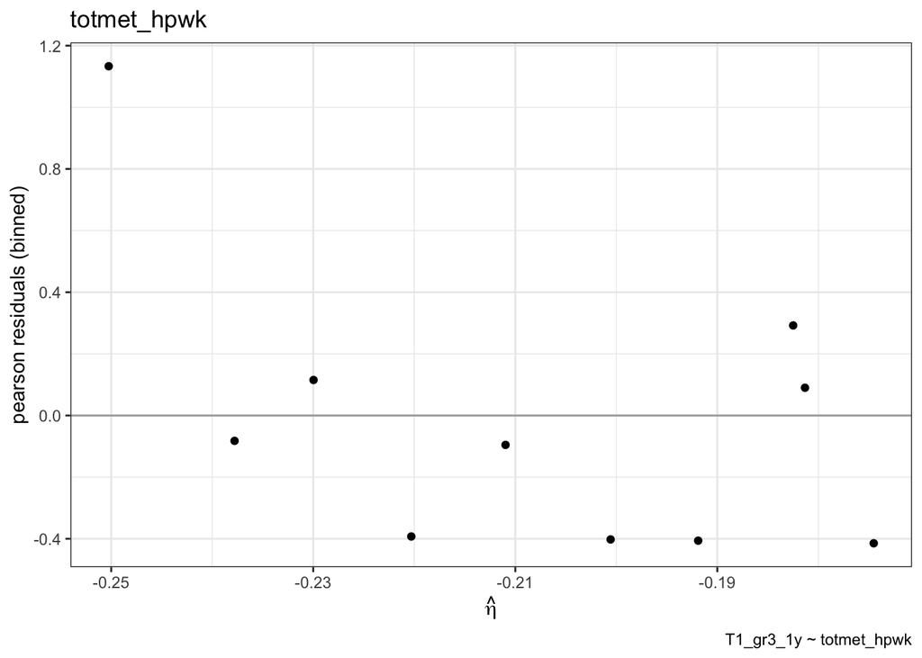

```r
fit <- glm(formula = T1_gr3_1y ~ totmet_hpwk , family = binomial(link = "logit"), data = tox_cICI)
residual_lp_binned(tox_cICI, fit = fit, title = "totmet_hpwk")
```

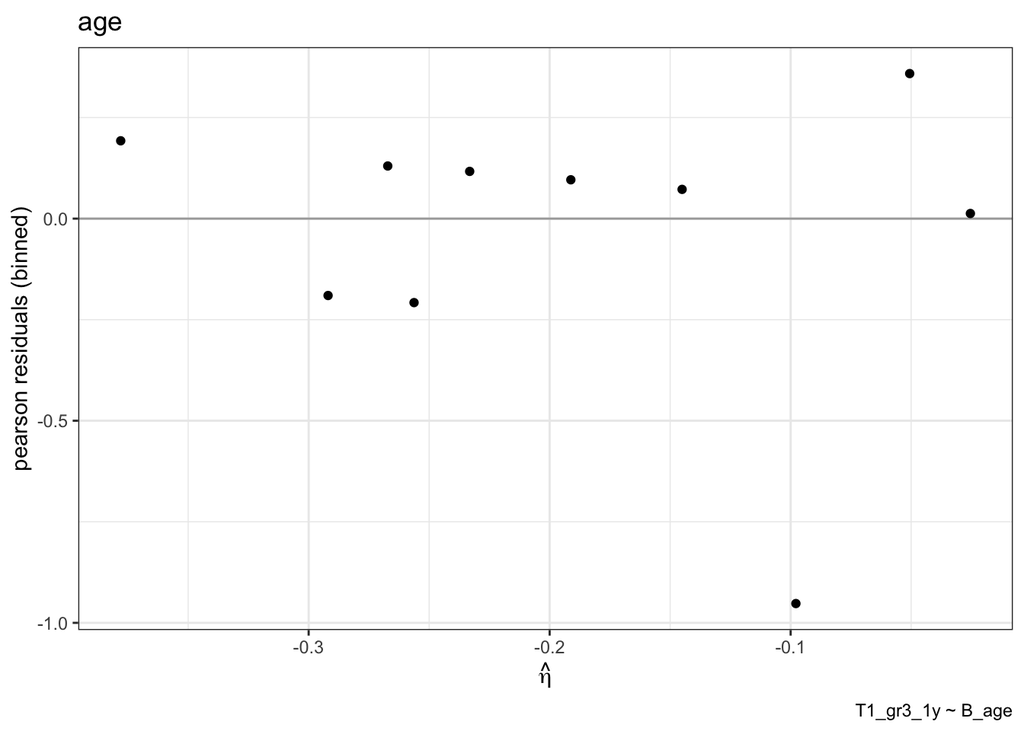

```r
fit <- glm(formula = T1_gr3_1y ~ B_age , family = binomial(link = "logit"), data = tox_cICI)
residual_lp_binned(tox_cICI, fit = fit, title = "age")
```

Assess whether residuals are normally distributed.

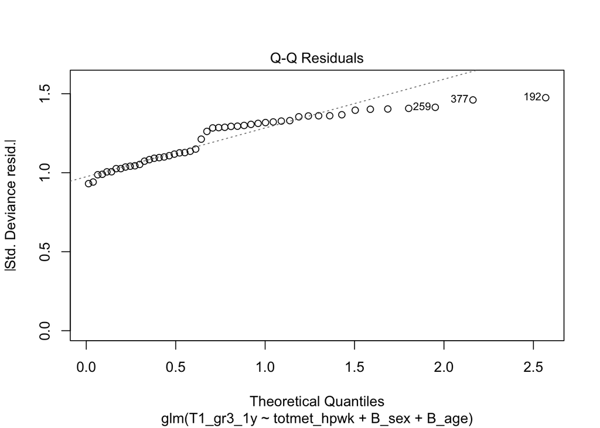

```r
plot(glm_lin.adj, which = 2)
```

Check homoscedasticity.

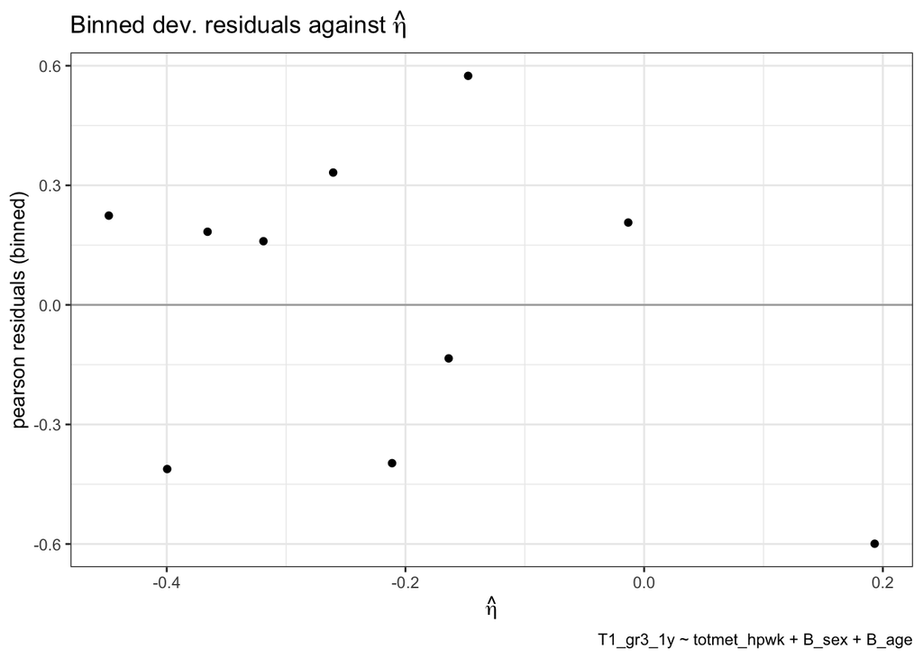

```r
residual_lp_binned(tox_cICI, glm_lin.adj)
```

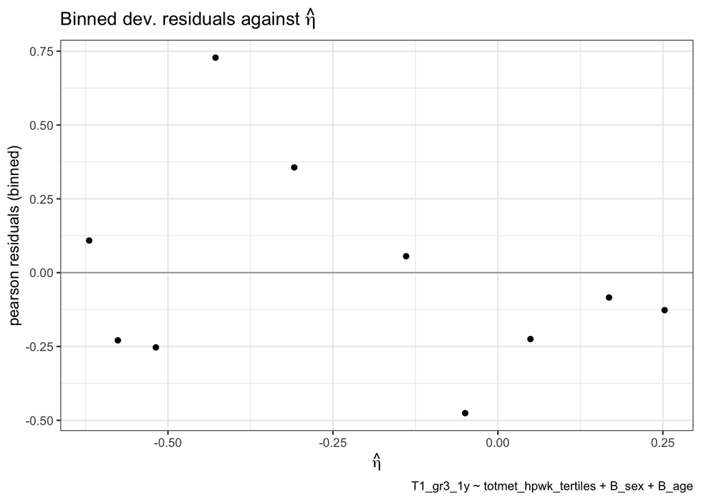

```r
residual_lp_binned(tox_cICI, glm_tert.adj)
```

### 5.2.4 SirAE~PA ipilimumab+nivolumab subgroup logistic regression - continuous splines

Specify knot locations **We will use the same knots as in the OS analysis.**

```r
k.pos.totmet_hpwk <- rcspline.eval(data_OS$totmet_hpwk #variable to use splines for
                            , nk=3 #number of knots
                            , inclx=FALSE
                            , knots.only=T #only store knots
                            , type="ordinary"
                            , norm=2
                            , rpm=NULL
                            , pc=FALSE
                            , fractied=0.05)
```

Initial regression.

```r
glm_rcs.adj <- glm(formula = T1_gr3_1y ~ rms::rcs(totmet_hpwk, k.pos.totmet_hpwk) + B_sex + B_age,
                   family = binomial(link = "logit"),
                   data = tox_cICI)
tbl_regression(glm_rcs.adj, exponentiate=T)
```

| **Characteristic** | **OR**<sup>1</sup> | **95% CI**<sup>1</sup> | **p-value** |
| --- | --- | --- | --- |
| totmet_hpwk |  |  |  |
| rms::rcs(totmet_hpwk, k.pos.totmet_hpwk)totmet_hpwk | 0.98 | 0.96, 1.01 | 0.2 |
| rms::rcs(totmet_hpwk, k.pos.totmet_hpwk)totmet_hpwk' | 1.02 | 1.00, 1.06 | 0.13 |
| B_sex |  |  |  |
| male | — | — |  |
| female | 1.61 | 0.45, 5.90 | 0.5 |
| B_age | 1.01 | 0.96, 1.06 | 0.7 |

<sup>1</sup> OR = Odds Ratio, CI = Confidence Interval

##### 5.2.4.0.1 Check added value of using splines

We can check whether using restricted cubic splines improves the model fit (statistically). A p-value <0.05 indicates that the model fit is statistically different.

We can check whether `totmet_hpwk` improves the model fit at all (compare a model with splines for `totmet_hpwk` (*Model 1*) to a model without `totmet_hpwk` (*Model 2*)).

```r
anova(glm_rcs.adj,update(glm_rcs.adj,.~.-rms::rcs(totmet_hpwk, k.pos.totmet_hpwk)), test = "Chisq")
```

```
## Analysis of Deviance Table
##
## Model 1: T1_gr3_1y ~ rms::rcs(totmet_hpwk, k.pos.totmet_hpwk) + B_sex +
##     B_age
## Model 2: T1_gr3_1y ~ B_sex + B_age
##   Resid. Df Resid. Dev Df Deviance Pr(>Chi)
## 1        44     63.846
## 2        46     66.469 -2  -2.6225   0.2695
```

Than, we check whether using splines for `totmet_hpwk` gives a better fit than adding it as a linear variable (compare a model with splines for `totmet_hpwk` (*Model 1*) to a model with `totmet_hpwk` as is (*Model 2*)).

```r
anova(glm_rcs.adj,update(glm_rcs.adj,.~.-rms::rcs(totmet_hpwk, k.pos.totmet_hpwk)+totmet_hpwk), test = "Chisq")
```

```
## Analysis of Deviance Table
##
## Model 1: T1_gr3_1y ~ rms::rcs(totmet_hpwk, k.pos.totmet_hpwk) + B_sex +
##     B_age
## Model 2: T1_gr3_1y ~ B_sex + B_age + totmet_hpwk
##   Resid. Df Resid. Dev Df Deviance Pr(>Chi)
## 1        44     63.846
## 2        45     66.455 -1  -2.6088   0.1063
```

Make dummy database.

```r
newdf <- tox_cICI

newdf$totmet_hpwk <- c(seq(min(tox_cICI$totmet_hpwk),max(tox_cICI$totmet_hpwk),length=(nrow(newdf)-length(k.pos.totmet_hpwk))), k.pos.totmet_hpwk)
```

Now we make a model matrix, which is needed in the subsequent steps.

```r
mm <- model.matrix(glm_rcs.adj, data=newdf)
mm[,!colnames(mm) %in% colnames(mm)[grep("totmet_hpwk",colnames(mm))]] <- 0 # set all variables not about totmet_hpwk to 0
```

For each value of our sequence of `totmet_hpwk`, we obtain its predicted coefficient (=`eta`) and predicted standard error (=`pse`). With these, we compute the predicted 95% conficence intervalls (`plo` and `phi` for lower and upper CI). We store these in a data frame called `est`.

```r
est <- data.frame(totmet_hpwk=newdf$totmet_hpwk,eta=mm%*%coef(glm_rcs.adj)) #predicted coefficient
pvar <- diag(mm %*% tcrossprod(vcov(glm_rcs.adj),mm)) #predicted variance
est <- data.frame(est,pse=sqrt(pvar)) #predicted standard error
est <- with(est,
            data.frame(est,
                       plo=eta-qnorm(0.975)*pse, #predicted lower 95%CI bound
                       phi=eta+qnorm(0.975)*pse)) #predicted upper 95%CI bound
```

For Cox regression and logistic regression we need to exponentiate the coefficient and confidence bounds to obtain OR and 95% CI.

```r
est[,c("eta","plo","phi")] <- exp(est[,c("eta","plo","phi")])
```

We remove duplicates (e.g. if we have two of the same values for `totmet_hpwk`) and sort on `totmet_hpwk`.

```r
est <- est[!duplicated(est),] #remove duplicates
est <- est[order(est$totmet_hpwk),] #sort based on var1 order
```

##### 5.2.4.0.2 Make splines plot

```r
p_splines_tox.OR_MET_cICI <- ggplot(data = est
                )+ geom_ribbon(aes(x=totmet_hpwk, ymin = plo, ymax = phi) #color 95%CI
                               , colour = rgb(248,136,44,maxColorValue = 255,alpha=100)
                               , fill=rgb(252,211,178,maxColorValue = 255,alpha=100)
                               , alpha=0.4
                )+ geom_hline(yintercept=1 #add horizontal line at 1
                              , color="dark grey"
                              , linetype="dashed"
                              , linewidth=1
                )+ geom_line(aes(x=totmet_hpwk,y=eta) #add estimated HR
                             , color = "coral3"
                             , linewidth = 1
                )+ geom_point(data=est[est$totmet_hpwk%in%k.pos.totmet_hpwk,] #to plot the places of the knots
                , aes(x=totmet_hpwk, y=eta)
                )+ geom_rug(data = tox_cICI, aes(x=totmet_hpwk) #add rugs representing real observations for totmet_hpwk
                            , sides = "b"
                            , length = grid::unit(0.02, "npc")
                            , color = "grey"
                            , alpha = .3
                )+ scale_x_continuous(expand = c(0, 0) #set axes directly at 0
                )+ scale_y_log10(breaks = unique(c(0.01,seq(0,1,.2)/10,seq(0,1,.2), seq(0,1,.2)*10))
                # )+ annotation_logticks(base = 10, sides = "l", outside=F , scaled = T, color = "black",alpha = .5
                )+ coord_cartesian(#xlim = c(0, 201) #set x-axis
                                   ylim = c(0.01,10) #set y-axis
                # )+ ggtitle("" #add title
                )+ xlab("MET-hours (/week)" #add x-axis label
                )+ ylab("Odds ratio for severe irAE" #add y-axis label
                )+ theme_light( #add/alter theme
                )+ theme(plot.margin = margin(0.5,3,0.5,0.5, unit = "char")
                )

p_splines_tox.OR_MET_cICI
```

[output not shown]

### 5.2.5 Visualize predicted probabilities of ficticious patient

Alternatively, we can visualize the predicted probabilities given a patient in whom only the variable of interest changes.

```r
newdf <- with(tox_cICI,
              expand.grid(totmet_hpwk=c(seq(min(totmet_hpwk),max(totmet_hpwk),length=300), k.pos.totmet_hpwk)
                          , B_sex = levels(B_sex)[1] #reference level for sex
                          , B_age = round(median(B_age), digits = 0)
                          ))
```

```r
newdf$prob <- predict(glm_rcs.adj, newdata = newdf, type = "response")
```

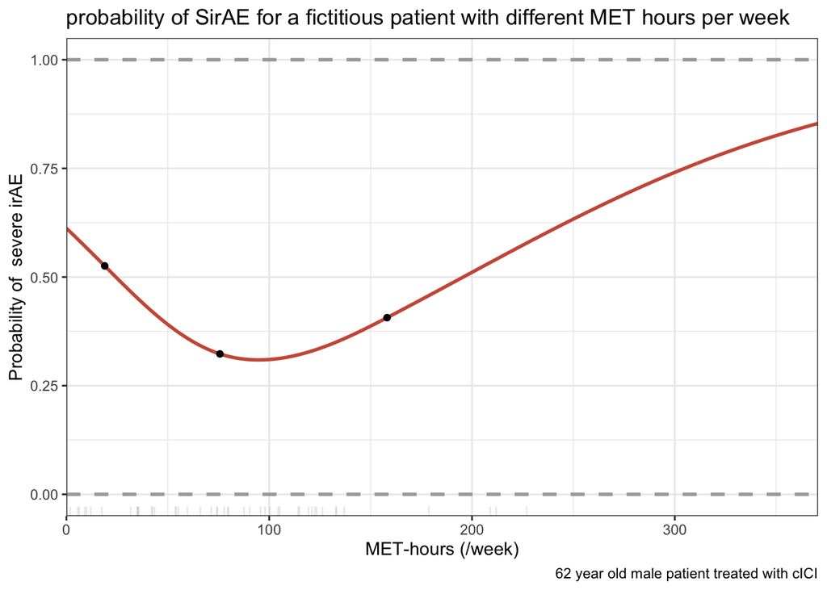

```r
p_splines_tox.prob_MET_cICI <- ggplot(data = newdf
                )+ geom_hline(yintercept=1 #add horizontal line at 1
                              , color="dark grey"
                              , linetype="dashed"
                              , linewidth=1
                )+ geom_hline(yintercept=0 #add horizontal line at 0
                              , color="dark grey"
                              , linetype="dashed"
                              , linewidth=1
                )+ geom_line(aes(x=totmet_hpwk,y=prob) #add estimated HR
                             , color = "coral3"
                             , linewidth = 1
                )+ geom_point(data=newdf[newdf$totmet_hpwk%in%k.pos.totmet_hpwk,] #to plot the places of the knots
                , aes(x=totmet_hpwk, y=prob)
                )+ geom_rug(data = tox_cICI, aes(x=totmet_hpwk) #add rugs representing real observations for totmet_hpwk
                            , sides = "b"
                            , length = grid::unit(0.02, "npc")
                            , color = "grey"
                            , alpha = .3
                )+ scale_x_continuous(expand = c(0, 0) #set axes directly at 0
                )+ coord_cartesian(#xlim = c(0, 201) #set x-axis
                                   ylim = c(0.0,1.0) #set y-axis
                )+ labs(x = "MET-hours (/week)" #add x-axis label
                        ,y ="Probability of  severe irAE" #add y-axis label
                        ,title = "probability of SirAE for a fictitious patient with different MET hours per week"
                        ,caption = "62 year old male patient treated with cICI"
                )+ theme_bw( #add/alter theme
                )

p_splines_tox.prob_MET_cICI
```

## 5.3 MVPA-SL and severe irAEs

### 5.3.1 SirAEs~MVPA-SL logistic regression - tertiles

Adjusted logistic regression for tertiles variable.

```r
glm_tert.adj <- glm(formula = T1_gr3_1y ~ MZvt_HWK_tertiles + B_sex + B_age,
                    family = binomial(link = "logit"),
                    data = tox_cICI)
tbl_regression(glm_tert.adj, exponentiate=T)
```

| **Characteristic** | **OR**<sup>1</sup> | **95% CI**<sup>1</sup> | **p-value** |
| --- | --- | --- | --- |
| MZvt_HWK_tertiles |  |  |  |
| [0,1.5] | — | — |  |
| (1.5,6.5] | 0.58 | 0.14, 2.26 | 0.4 |
| (6.5,38.5] | 0.31 | 0.06, 1.41 | 0.14 |
| B_sex |  |  |  |
| male | — | — |  |
| female | 1.34 | 0.37, 4.92 | 0.7 |
| B_age | 1.02 | 0.97, 1.07 | 0.4 |

<sup>1</sup> OR = Odds Ratio, CI = Confidence Interval

### 5.3.2 SirAEs~MVPA-SL logistic regression - continuous linear

Adjusted logistic regression for continuous linear variable.

```r
glm_lin.adj <- glm(formula = T1_gr3_1y ~ MZvt_HWK + B_sex + B_age,
                   family = binomial(link = "logit"),
                   data = tox_cICI)
tbl_regression(glm_lin.adj, exponentiate=T)
```

| **Characteristic** | **OR**<sup>1</sup> | **95% CI**<sup>1</sup> | **p-value** |
| --- | --- | --- | --- |
| MZvt_HWK | 0.95 | 0.85, 1.05 | 0.4 |
| B_sex |  |  |  |
| male | — | — |  |
| female | 1.48 | 0.42, 5.32 | 0.5 |
| B_age | 1.02 | 0.97, 1.07 | 0.5 |

<sup>1</sup> OR = Odds Ratio, CI = Confidence Interval

###SirAEs~MVPA-SL logistic regression - assumptions

Assess linearity of `MZvt_HWK` and `B_age` with outcome.

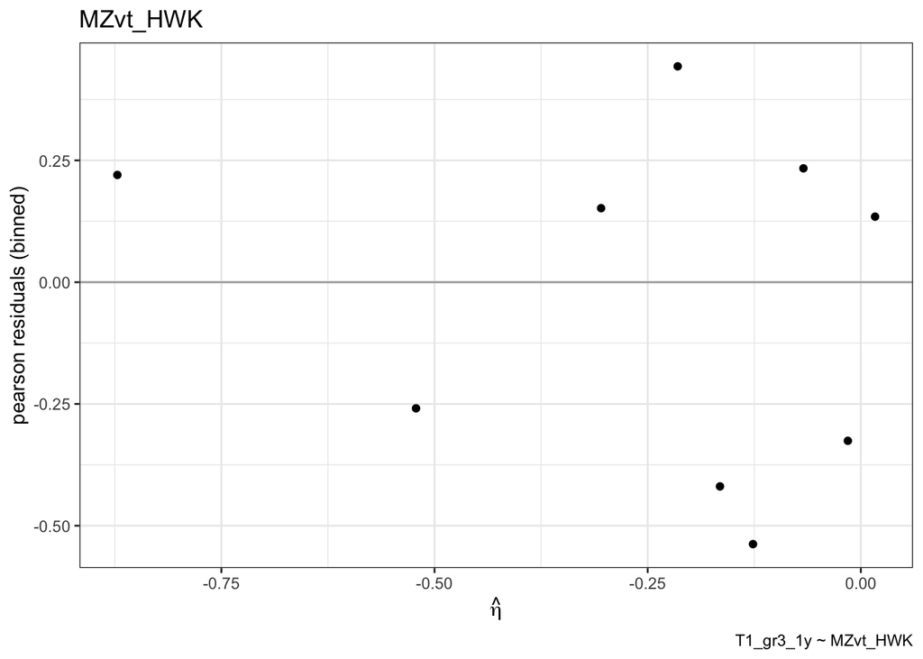

```r
fit <- glm(formula = T1_gr3_1y ~ MZvt_HWK , family = binomial(link = "logit"), data = tox_cICI)
residual_lp_binned(tox_cICI, fit = fit, title = "MZvt_HWK")
```

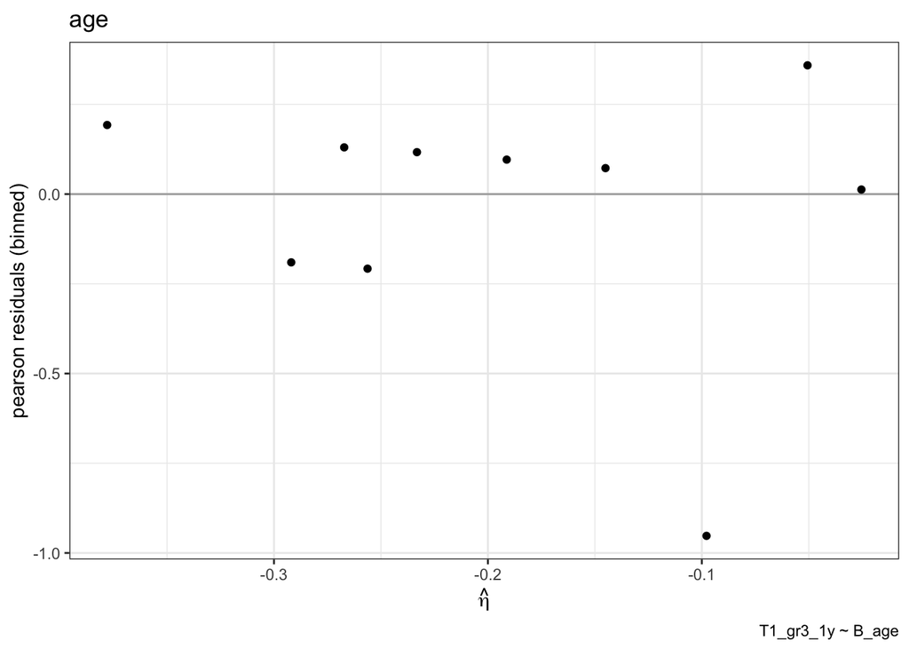

```r
fit <- glm(formula = T1_gr3_1y ~ B_age , family = binomial(link = "logit"), data = tox_cICI)
residual_lp_binned(tox_cICI, fit = fit, title = "age")
```

Assess whether residuals are normally distributed.

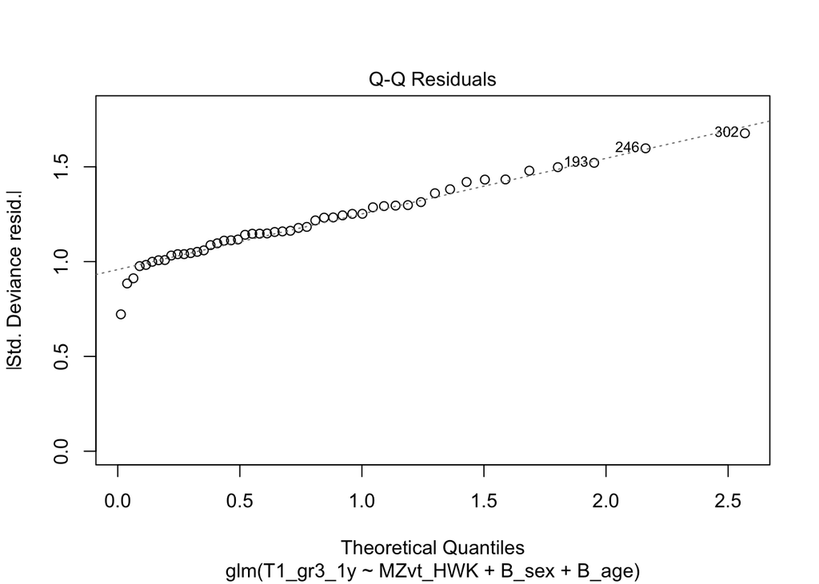

```r
plot(glm_lin.adj, which = 2)
```

Check homoscedasticity.

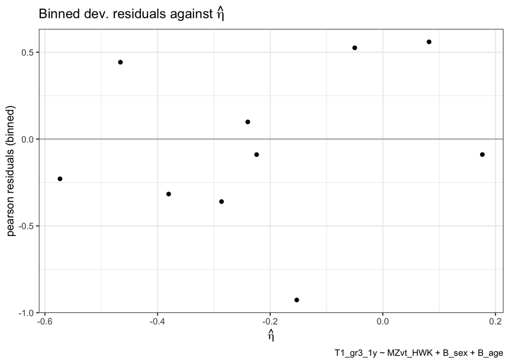

```r
residual_lp_binned(tox_cICI, glm_lin.adj)
```

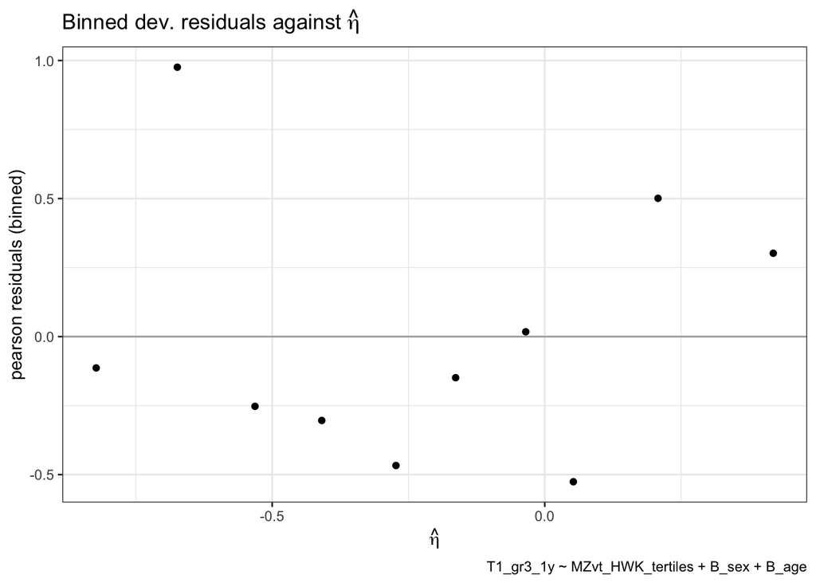

```r
residual_lp_binned(tox_cICI, glm_tert.adj)
```

### 5.3.3 SirAEs~MVPA-SL logistic regression - continuous splines

Specify knots locations. **We will use the same knots as in the OS analysis.**

```r
k.pos.MZvt_HWK <- rcspline.eval(data_OS$MZvt_HWK #variable to use splines for
                            , nk=3 #number of knots
                            , inclx=FALSE
                            , knots.only=T #only store knots
                            , type="ordinary"
                            , norm=2
                            , rpm=NULL
                            , pc=FALSE
                            , fractied=0.05)
```

Initial regression.

```r
glm_rcs.adj <- glm(formula = T1_gr3_1y ~ rms::rcs(MZvt_HWK, k.pos.MZvt_HWK) + B_sex + B_age,
                   family = binomial(link = "logit"),
                   data = tox_cICI)
tbl_regression(glm_rcs.adj, exponentiate=T)
```

| **Characteristic** | **OR**<sup>1</sup> | **95% CI**<sup>1</sup> | **p-value** |
| --- | --- | --- | --- |
| MZvt_HWK |  |  |  |
| rms::rcs(MZvt_HWK, k.pos.MZvt_HWK)MZvt_HWK | 0.92 | 0.67, 1.28 | 0.6 |
| rms::rcs(MZvt_HWK, k.pos.MZvt_HWK)MZvt_HWK' | 1.06 | 0.57, 1.89 | 0.8 |
| B_sex |  |  |  |
| male | — | — |  |
| female | 1.46 | 0.41, 5.28 | 0.6 |
| B_age | 1.02 | 0.97, 1.07 | 0.5 |

<sup>1</sup> OR = Odds Ratio, CI = Confidence Interval

##### 5.3.3.0.1 Check added value of using splines

We can check whether using restricted cubic splines improves the model fit (statistically). A p-value <0.05 indicates that the model fit is statistically different.

We can check whether `MZvt_HWK` improves the model fit at all (compare a model with splines for `MZvt_HWK` (*Model 1*) to a model without `MZvt_HWK` (*Model 2*)).

```r
anova(glm_rcs.adj,update(glm_rcs.adj,.~.-rms::rcs(MZvt_HWK, k.pos.MZvt_HWK)), test = "Chisq")
```

```
## Analysis of Deviance Table
##
## Model 1: T1_gr3_1y ~ rms::rcs(MZvt_HWK, k.pos.MZvt_HWK) + B_sex + B_age
## Model 2: T1_gr3_1y ~ B_sex + B_age
##   Resid. Df Resid. Dev Df Deviance Pr(>Chi)
## 1        44     65.557
## 2        46     66.469 -2 -0.91148    0.634
```

Than, we check whether using splines for `MZvt_HWK` gives a better fit than adding it as a linear variable (compare a model with splines for `MZvt_HWK` (*Model 1*) to a model with `MZvt_HWK` as is (*Model 2*)).

```r
anova(glm_rcs.adj,update(glm_rcs.adj,.~.-rms::rcs(MZvt_HWK, k.pos.MZvt_HWK)+MZvt_HWK), test = "Chisq")
```

```
## Analysis of Deviance Table
##
## Model 1: T1_gr3_1y ~ rms::rcs(MZvt_HWK, k.pos.MZvt_HWK) + B_sex + B_age
## Model 2: T1_gr3_1y ~ B_sex + B_age + MZvt_HWK
##   Resid. Df Resid. Dev Df Deviance Pr(>Chi)
## 1        44     65.557
## 2        45     65.598 -1 -0.04129    0.839
```

Make dummy dataset

```r
newdf <- tox_cICI

newdf$MZvt_HWK <- c(seq(min(tox_cICI$MZvt_HWK),max(tox_cICI$MZvt_HWK),length=(nrow(newdf)-length(k.pos.MZvt_HWK))), k.pos.MZvt_HWK)
```

Now we make a model matrix, which is needed in the subsequent steps.

```r
mm <- model.matrix(glm_rcs.adj, data=newdf)
mm[,!colnames(mm) %in% colnames(mm)[grep("MZvt_HWK",colnames(mm))]] <- 0 # set all variables not about MZvt_HWK to 0
```

For each value of our sequence of `MZvt_HWK`, we obtain its predicted coefficient (=`eta`) and predicted standard error (=`pse`). With these, we compute the predicted 95% conficence intervalls (`plo` and `phi` for lower and upper CI). We store these in a data frame called `est`.

```r
est <- data.frame(MZvt_HWK=newdf$MZvt_HWK,eta=mm%*%coef(glm_rcs.adj)) #predicted coefficient
pvar <- diag(mm %*% tcrossprod(vcov(glm_rcs.adj),mm)) #predicted variance
est <- data.frame(est,pse=sqrt(pvar)) #predicted standard error
est <- with(est,
            data.frame(est,
                       plo=eta-qnorm(0.975)*pse, #predicted lower 95%CI bound
                       phi=eta+qnorm(0.975)*pse)) #predicted upper 95%CI bound
```

For Cox regression and logistic regression we need to exponentiate the coefficient and confidence bounds to obtain OR and 95% CI.

```r
est[,c("eta","plo","phi")] <- exp(est[,c("eta","plo","phi")])
```

We remove duplicates (e.g. if we have two of the same values for `MZvt_HWK`) and sort on `MZvt_HWK`.

```r
est <- est[!duplicated(est),] #remove duplicates
est <- est[order(est$MZvt_HWK),] #sort based on var1 order
```

##### 5.3.3.0.2 Make splines plot

```r
p_splines_tox.OR_MVPASL_cICI <- ggplot(data = est
                )+ geom_ribbon(aes(x=MZvt_HWK, ymin = plo, ymax = phi) #color 95%CI
                               , colour = rgb(248,136,44,maxColorValue = 255,alpha=100)
                               , fill=rgb(252,211,178,maxColorValue = 255,alpha=100)
                               , alpha=0.4
                )+ geom_hline(yintercept=1 #add horizontal line at 1
                              , color="dark grey"
                              , linetype="dashed"
                              , linewidth=1
                )+ geom_line(aes(x=MZvt_HWK,y=eta) #add estimated HR
                             , color = "coral3"
                             , linewidth = 1
                )+ geom_point(data=est[est$MZvt_HWK%in%k.pos.MZvt_HWK,] #to plot the places of the knots
                , aes(x=MZvt_HWK, y=eta)
                )+ geom_rug(data = tox_cICI, aes(x=MZvt_HWK) #add rugs representing real observations for MZvt_HWK
                            , sides = "b"
                            , length = grid::unit(0.02, "npc")
                            , color = "grey"
                            , alpha = .3
                )+ scale_x_continuous(expand = c(0, 0) #set axes directly at 0
                )+ scale_y_log10(breaks = unique(c(0.01,seq(0,1,.2)/10,seq(0,1,.2), seq(0,1,.2)*10))
                )+ coord_cartesian(#xlim = c(0, 201) #set x-axis
                                   ylim = c(0.01,10) #set y-axis
                # )+ ggtitle("" #add title
                )+ xlab("MVPA-SL (hours/week)" #add x-axis label
                )+ ylab("Odds ratio for severe irAE" #add y-axis label
                )+ theme_light( #add/alter theme
                )+ theme(plot.margin = margin(0.5,3,0.5,0.5, unit = "char")
                )

p_splines_tox.OR_MVPASL_cICI
```

[output not shown]

### 5.3.4 Visualize predicted probabilities of ficticious patient

Alternatively, we can visualize the predicted probabilities given a patient in whom only the variable of interest changes.

```r
newdf <- with(tox_cICI,
              expand.grid(MZvt_HWK=c(seq(min(MZvt_HWK),max(MZvt_HWK),length=300), k.pos.MZvt_HWK)
                          , B_sex = levels(B_sex)[1] #reference level for sex
                          , B_age = round(median(B_age), digits = 0)
                          ))
median(tox_cICI$B_age)
```

```
## [1] 62
```

```r
newdf$prob <- predict(glm_rcs.adj, newdata = newdf, type = "response")
```

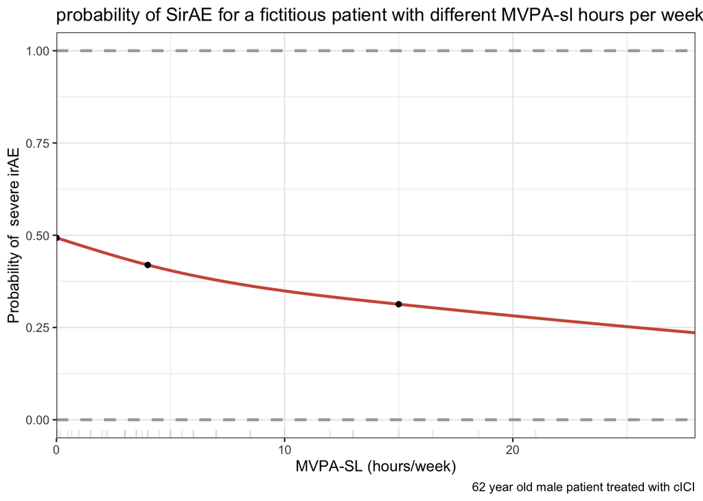

```r
p_splines_tox.prob_MVPASL_cICI <- ggplot(data = newdf
                )+ geom_hline(yintercept=1 #add horizontal line at 1
                              , color="dark grey"
                              , linetype="dashed"
                              , linewidth=1
                )+ geom_hline(yintercept=0 #add horizontal line at 0
                              , color="dark grey"
                              , linetype="dashed"
                              , linewidth=1
                )+ geom_line(aes(x=MZvt_HWK,y=prob) #add estimated HR
                             , color = "coral3"
                             , linewidth = 1
                )+ geom_point(data=newdf[newdf$MZvt_HWK%in%k.pos.MZvt_HWK,] #to plot the places of the knots
                , aes(x=MZvt_HWK, y=prob)
                )+ geom_rug(data = tox_cICI, aes(x=MZvt_HWK) #add rugs representing real observations for MZvt_HWK
                            , sides = "b"
                            , length = grid::unit(0.02, "npc")
                            , color = "grey"
                            , alpha = .3
                )+ scale_x_continuous(expand = c(0, 0) #set axes directly at 0
                )+ coord_cartesian(#xlim = c(0, 201) #set x-axis
                                   ylim = c(0.0,1.0) #set y-axis
                )+ labs(x = "MVPA-SL (hours/week)" #add x-axis label
                        ,y ="Probability of  severe irAE" #add y-axis label
                        ,title = "probability of SirAE for a fictitious patient with different MVPA-sl hours per week"
                        ,caption = "62 year old male patient treated with cICI"
                )+ theme_bw( #add/alter theme
                )

p_splines_tox.prob_MVPASL_cICI
```

## 5.4 Combine all irAE plots

Make Supplementary Figure 2.

```r
suppl_figure2 <- ggarrange(p_splines_tox.OR_MET_cICI, p_splines_tox.OR_MVPASL_cICI
                     ,labels = c("A","B")
                     ,ncol=2, nrow=1
                     ,widths = c(1,1), heights = c(1,1)
                     ,common.legend=F
                     )
suppl_figure2
```

[output not shown]

Save as PDF.

# 6 SirAE~PA Competing risk

Death might be a competing risk for irAE occurrence. In other words: patients who die early might not have survived long enough to have an irAE although they would have had one if they would have lived longer. The **proportional subdistribution hazard model** as described by Fine and Gray (FG), infers the rate of occurrence of the event (irAE) in patients who have not yet experienced that specific event, including patients who have experienced the competing event (death). While the Fine and Gray model provides us a Hazard Ratio (HR), we can obtain a graphical representation by plotting the cumulative incidence function.

We will use the data frame `data_OS`: data from all SQUASH respondents with survival data.

For competing risk analyses, a variable is needed reflecting all possible outcomes: - `censor` =censored; - `SirAE` =developed severe irAE; - `death` =died before developing a severe irAE (in our case all deaths were caused by disease progression).

## 6.1 SirAE~MET Cumulative incidence function - tertiles

Estimate the cumulative incidence in the context of competing risks using the `cuminc()` function from the `tidycmprsk` package, which is a wrapper around the `cmprsk` package by Gray. We can now obtain the cumulative incidence at a specific time point. To visualize the cumulative incidence function, we will use the `ggcumic()` function from the `ggsurvfit` package.

```r
cif_tert.crude_MET <- tidycmprsk::cuminc(Surv(T1_gr3_days, T1_gr3_status) ~ totmet_hpwk_tertiles, data = data_OS)

tidycmprsk::tbl_cuminc(cif_tert.crude_MET,
                       times = 12*30.4375,
                       outcomes = c("SirAE" , "death"),
                       label_header = "1-year cuminc"
                       ) #%>%
```

| **Characteristic** | 1-year cuminc |
| --- | --- |
| SirAE |  |
| totmet_hpwk_tertiles |  |
| [0,51] | 30% (20%, 40%) |
| (51,101] | 13% (7.1%, 22%) |
| (101,371] | 13% (7.0%, 21%) |
| death |  |
| totmet_hpwk_tertiles |  |
| [0,51] | 28% (19%, 39%) |
| (51,101] | 12% (5.5%, 21%) |
| (101,371] | 11% (4.9%, 19%) |

```r
  # add_p() #to add p-value


cuminc_MET <- ggcuminc(cif_tert.crude_MET,
                       outcome = c("death", "SirAE")
                       ,theme = list(theme_ggsurvfit_default(),theme(legend.position = "right"))
                       # ) + add_confidence_interval(
                       ) + add_risktable(risktable_stats = "n.risk"
                       ) + labs(x = "Time (months)"
                                ,color = "MET-hours"
                                ,linetype = "outcome"
                       ) + coord_cartesian(ylim = c(0,0.5)
                       )
cuminc_MET
```

[output not shown]

## 6.2 SirAE~MET FG - tertiles

For the subdistribution hazard regression, we will use the `crr()` function from the `tidycmprsk` package.

```r
crr_tert.adj_MET <- tidycmprsk::crr(Surv(T1_gr3_days, T1_gr3_status) ~ totmet_hpwk_tertiles + B_sex + B_age + B_tumor_type.1 + B_paladj + B_ther_cur_regrouped.1,
                                failcode = "SirAE",
                                data = data_OS)
tbl_regression(crr_tert.adj_MET, exponentiate=T)
```

| **Characteristic** | **HR**<sup>1</sup> | **95% CI**<sup>1</sup> | **p-value** |
| --- | --- | --- | --- |
| totmet_hpwk_tertiles |  |  |  |
| [0,51] | — | — |  |
| (51,101] | 0.46 | 0.21, 1.03 | 0.058 |
| (101,371] | 0.43 | 0.21, 0.90 | 0.025 |
| B_sex |  |  |  |
| male | — | — |  |
| female | 1.27 | 0.63, 2.55 | 0.5 |
| B_age | 1.02 | 0.99, 1.05 | 0.3 |
| B_tumor_type.1 |  |  |  |
| melanoma | — | — |  |
| NSCLC | 0.84 | 0.21, 3.41 | 0.8 |
| RCC | 0.52 | 0.21, 1.32 | 0.2 |
| other | 0.51 | 0.13, 1.97 | 0.3 |
| B_paladj |  |  |  |
| palliative | — | — |  |
| adjuvant | 0.59 | 0.18, 1.99 | 0.4 |
| B_ther_cur_regrouped.1 |  |  |  |
| anti-PD-(L)1 | — | — |  |
| cICI | 8.12 | 3.19, 20.7 | <0.001 |
| ICI + chemo/targeted therapy | 2.06 | 0.62, 6.86 | 0.2 |

<sup>1</sup> HR = Hazard Ratio, CI = Confidence Interval

## 6.3 SirAE~MVPA-SL Cumulative incidence function - tertiles

Estimate the cumulative incidence in the context of competing risks using the `cuminc()` function from the `tidycmprsk` package, which is a wrapper around the `cmprsk` package by Gray. We can now obtain the cumulative incidence at a specific time point. To visualize the cumulative incidence function, we will use the `ggcumic()` function from the `ggsurvfit` package.

```r
cif_tert.crude_MVPASL <- tidycmprsk::cuminc(Surv(T1_gr3_days, T1_gr3_status) ~ MZvt_HWK_tertiles, data = data_OS)

tidycmprsk::tbl_cuminc(cif_tert.crude_MVPASL,
                       times = 12*30.4375,
                       outcomes = c("SirAE" , "death"),
                       label_header = "1-year cuminc"
                       ) #%>%
```

| **Characteristic** | 1-year cuminc |
| --- | --- |
| SirAE |  |
| MZvt_HWK_tertiles |  |
| [0,1.5] | 29% (20%, 39%) |
| (1.5,6.5] | 15% (8.1%, 24%) |
| (6.5,38.5] | 11% (5.6%, 20%) |
| death |  |
| MZvt_HWK_tertiles |  |
| [0,1.5] | 27% (17%, 37%) |
| (1.5,6.5] | 14% (6.9%, 23%) |
| (6.5,38.5] | 9.9% (4.3%, 18%) |

```r
  # add_p() #to add p-value


cuminc_MVPASL <- ggcuminc(cif_tert.crude_MVPASL,
                          outcome = c("death", "SirAE")
                          ,theme = list(theme_ggsurvfit_default(),theme(legend.position = "right"))
                          # ) + add_confidence_interval(
                          ) + add_risktable(risktable_stats = "n.risk"
                          ) + labs(x = "Time (months)"
                                   ,color = "MVPA-SL"
                                   ,linetype = "outcome"
                          ) + coord_cartesian(ylim = c(0,0.5)
                          )
cuminc_MVPASL
```

[output not shown]

## 6.4 SirAE~MVPA-SL FG - tertiles

For the subdistribution hazard regression, we will use the `crr()` function from the `tidycmprsk` package.

```r
crr_tert.adj_MVPASL <- tidycmprsk::crr(Surv(T1_gr3_days, T1_gr3_status) ~ MZvt_HWK_tertiles + B_sex + B_age + B_tumor_type.1 + B_paladj + B_ther_cur_regrouped.1,
                                failcode = "SirAE",
                                data = data_OS)
tbl_regression(crr_tert.adj_MVPASL, exponentiate=T)
```

| **Characteristic** | **HR**<sup>1</sup> | **95% CI**<sup>1</sup> | **p-value** |
| --- | --- | --- | --- |
| MZvt_HWK_tertiles |  |  |  |
| [0,1.5] | — | — |  |
| (1.5,6.5] | 0.59 | 0.28, 1.23 | 0.2 |
| (6.5,38.5] | 0.37 | 0.16, 0.86 | 0.020 |
| B_sex |  |  |  |
| male | — | — |  |
| female | 1.10 | 0.55, 2.18 | 0.8 |
| B_age | 1.02 | 0.99, 1.06 | 0.2 |
| B_tumor_type.1 |  |  |  |
| melanoma | — | — |  |
| NSCLC | 0.85 | 0.18, 4.08 | 0.8 |
| RCC | 0.55 | 0.22, 1.38 | 0.2 |
| other | 0.54 | 0.14, 2.13 | 0.4 |
| B_paladj |  |  |  |
| palliative | — | — |  |
| adjuvant | 0.60 | 0.17, 2.11 | 0.4 |
| B_ther_cur_regrouped.1 |  |  |  |
| anti-PD-(L)1 | — | — |  |
| cICI | 7.68 | 2.87, 20.5 | <0.001 |
| ICI + chemo/targeted therapy | 2.11 | 0.58, 7.72 | 0.3 |

<sup>1</sup> HR = Hazard Ratio, CI = Confidence Interval

## 6.5 Combine cumulative incidence plots

Make Supplementary Figure 3.

```r
suppl_figure3 <- ggarrange(cuminc_MET, cuminc_MVPASL
                     ,labels = c("A","B")
                     ,ncol=2, nrow=1
                     ,widths = c(1,1), heights = c(1,1)
                     ,common.legend=F
                     )
suppl_figure3
```

[output not shown]

Save as PDF.